# Bài thực hành số 1: Dự đoán giá nhà ở California

Tác giả: Nguyễn Nhật Quang

2026-06-27

# 1 Giới thiệu

Bộ dữ liệu California Housing gồm **20,640** quan sát ở cấp **census block group** tại bang California, dựa trên dữ liệu điều tra dân số năm 1990 và được cung cấp qua Kaggle (`https://www.kaggle.com/datasets/camnugent/california-housing-prices/data`). Mục tiêu của bài thực hành là xây dựng mô hình dự đoán `median_house_value`, tức giá trị nhà trung vị của một khu vực, dựa trên các đặc trưng địa lý, nhân khẩu học, thu nhập và vị trí so với biển.

Cần lưu ý rằng mỗi dòng dữ liệu không đại diện cho một căn nhà riêng lẻ. Các biến như `total_rooms`, `population` và `households` là số liệu tổng hợp ở cấp khu vực điều tra dân số.

**Research question:** Các yếu tố nào dự đoán `median_house_value` tốt nhất? Các mô hình tuyến tính có regularization (Ridge, LASSO, Elastic Net) có cải thiện đáng kể so với hồi quy tuyến tính bội ước lượng bằng OLS không?

# 2 Đọc dữ liệu

```r
housing <- read.csv("../California_housing.csv", stringsAsFactors = FALSE)

dim(housing)
```

```
## [1] 20640    10
```

```r
str(housing)
```

```
## 'data.frame':    20640 obs. of  10 variables:
##  $ longitude         : num  -122 -122 -122 -122 -122 ...
##  $ latitude          : num  37.9 37.9 37.9 37.9 37.9 ...
##  $ housing_median_age: num  41 21 52 52 52 52 52 52 42 52 ...
##  $ total_rooms       : num  880 7099 1467 1274 1627 ...
##  $ total_bedrooms    : num  129 1106 190 235 280 ...
##  $ population        : num  322 2401 496 558 565 ...
##  $ households        : num  126 1138 177 219 259 ...
##  $ median_income     : num  8.33 8.3 7.26 5.64 3.85 ...
##  $ median_house_value: num  452600 358500 352100 341300 342200 ...
##  $ ocean_proximity   : chr  "NEAR BAY" "NEAR BAY" "NEAR BAY" "NEAR BAY" ...
```

```r
head(housing) |>
  kable(caption = "Một số quan sát đầu tiên trong dữ liệu")
```

Một số quan sát đầu tiên trong dữ liệu

| longitude | latitude | housing_median_age | total_rooms | total_bedrooms | population | households | median_income | median_house_value | ocean_proximity |
| --- | --- | --- | --- | --- | --- | --- | --- | --- | --- |
| -122.23 | 37.88 | 41 | 880 | 129 | 322 | 126 | 8.3252 | 452600 | NEAR BAY |
| -122.22 | 37.86 | 21 | 7099 | 1106 | 2401 | 1138 | 8.3014 | 358500 | NEAR BAY |
| -122.24 | 37.85 | 52 | 1467 | 190 | 496 | 177 | 7.2574 | 352100 | NEAR BAY |
| -122.25 | 37.85 | 52 | 1274 | 235 | 558 | 219 | 5.6431 | 341300 | NEAR BAY |
| -122.25 | 37.85 | 52 | 1627 | 280 | 565 | 259 | 3.8462 | 342200 | NEAR BAY |
| -122.25 | 37.85 | 52 | 919 | 213 | 413 | 193 | 4.0368 | 269700 | NEAR BAY |

```r
# Tính min/max từ data cho tất cả biến numeric
num_range <- function(var, digits = 1, fmt = NULL) {
  vals <- housing[[var]]
  lo <- min(vals, na.rm = TRUE)
  hi <- max(vals, na.rm = TRUE)
  if (is.null(fmt)) {
    paste0(round(lo, digits), " – ", round(hi, digits))
  } else {
    paste0(fmt(lo), " – ", fmt(hi))
  }
}

# Các mức của biến phân loại, lấy thẳng từ data và sắp xếp
ocean_levels <- paste(sort(unique(housing$ocean_proximity)), collapse = " / ")

# Một ví dụ minh họa đơn vị median_income: lấy median rồi quy đổi
income_example <- median(housing$median_income, na.rm = TRUE)

data_dict <- data.frame(
  variable = c(
    "longitude", "latitude", "housing_median_age",
    "total_rooms", "total_bedrooms", "population",
    "households", "median_income", "median_house_value", "ocean_proximity"
  ),
  description = c(
    "Kinh độ của census block group",
    "Vĩ độ của census block group",
    "Tuổi trung vị của các căn nhà trong khu vực",
    "Tổng số phòng trong khu vực (tất cả hộ gia đình)",
    "Tổng số phòng ngủ trong khu vực",
    "Tổng dân số trong khu vực",
    "Số hộ gia đình trong khu vực",
    "Thu nhập trung vị hộ gia đình",
    "Giá trị nhà trung vị (biến mục tiêu, bị chặn trên)",
    "Vị trí tương đối so với biển"
  ),
  unit_range = c(
    paste0("Độ thập phân (", num_range("longitude"), ")"),
    paste0("Độ thập phân (", num_range("latitude"), ")"),
    paste0("Năm (", num_range("housing_median_age", digits = 0), ")"),
    paste0("Tổng phòng, cấp khu vực (", num_range("total_rooms", fmt = function(x) format(round(x, 0), big.mark = ",")), ")"),
    paste0("Tổng phòng ngủ, cấp khu vực (", num_range("total_bedrooms", fmt = function(x) format(round(x, 0), big.mark = ",")), ")"),
    paste0("Tổng người, cấp khu vực (", num_range("population", fmt = function(x) format(round(x, 0), big.mark = ",")), ")"),
    paste0("Số hộ (", num_range("households", fmt = function(x) format(round(x, 0), big.mark = ",")), ")"),
    paste0("Chục nghìn USD, median = ", round(income_example, 2), " ≈ $", round(income_example * 10, 0), "k; khoảng (", num_range("median_income"), ")"),
    paste0("USD (", num_range("median_house_value", fmt = dollar), ")"),
    ocean_levels
  )
)

data_dict |>
  kable(
    col.names = c("Biến", "Mô tả", "Đơn vị / Khoảng giá trị"),
    caption = "Data dictionary: ý nghĩa và đơn vị các biến"
  )
```

Data dictionary: ý nghĩa và đơn vị các biến

| Biến | Mô tả | Đơn vị / Khoảng giá trị |
| --- | --- | --- |
| longitude | Kinh độ của census block group | Độ thập phân (-124.3 – -114.3) |
| latitude | Vĩ độ của census block group | Độ thập phân (32.5 – 42) |
| housing_median_age | Tuổi trung vị của các căn nhà trong khu vực | Năm (1 – 52) |
| total_rooms | Tổng số phòng trong khu vực (tất cả hộ gia đình) | Tổng phòng, cấp khu vực (2 – 39,320) |
| total_bedrooms | Tổng số phòng ngủ trong khu vực | Tổng phòng ngủ, cấp khu vực (1 – 6,445) |
| population | Tổng dân số trong khu vực | Tổng người, cấp khu vực (3 – 35,682) |
| households | Số hộ gia đình trong khu vực | Số hộ (1 – 6,082) |
| median_income | Thu nhập trung vị hộ gia đình | Chục nghìn USD, median = 3.53 ≈ $35k; khoảng (0.5 – 15) |
| median_house_value | Giá trị nhà trung vị (biến mục tiêu, bị chặn trên) | USD ($14,999 – $500,001) |
| ocean_proximity | Vị trí tương đối so với biển | <1H OCEAN / INLAND / ISLAND / NEAR BAY / NEAR OCEAN |

```r
n_duplicates <- sum(duplicated(housing))
n_duplicates
```

```
## [1] 0
```

Số bản ghi trùng lặp hoàn toàn trong dataset: 0. Không có duplicate nên không cần xử lý thêm bước này.

# 3 Khám phá dữ liệu

Trước khi xây dựng mô hình, việc khám phá các đặc trưng của bộ dữ liệu được thực hiện theo hai mục tiêu chính:

**Kiểm tra chất lượng dữ liệu:** xác minh xem dữ liệu có các vấn đề cần xử lý trước không, bao gồm giá trị thiếu, outlier bất thường, phân phối lệch nặng, và giá trị bị chặn nhân tạo (ví dụ `median_house_value` bị capping ở `$500,001`).

**Định hướng xây dựng biến và lựa chọn mô hình:** các giả thuyết dưới đây sẽ được kiểm chứng bằng đồ thị và thống kê mô tả, từ đó quyết định cách tạo biến mới và lựa chọn dạng mô hình:

- *Vị trí địa lý là yếu tố chủ đạo:* giá nhà ven biển cao hơn nội địa, cần giữ cả `longitude`, `latitude` lẫn `ocean_proximity` vì mỗi biến capture một khía cạnh khác nhau của không gian.
- *Thu nhập có quan hệ phi tuyến với giá nhà:* kỳ vọng tương quan mạnh nhưng có thể không tuyến tính, kiểm tra bằng scatter plot.
- *Các biến đếm cấp khu vực bị đa cộng tuyến:* `total_rooms`, `total_bedrooms`, `population`, `households` đo cùng một “quy mô khu vực”, cần tạo ratio variables để đưa vào mô hình.
- *Phân phối biến mục tiêu lệch phải:* cần kiểm tra xem log-transform có phù hợp không.

## 3.1 Trực quan giá nhà theo khu vực

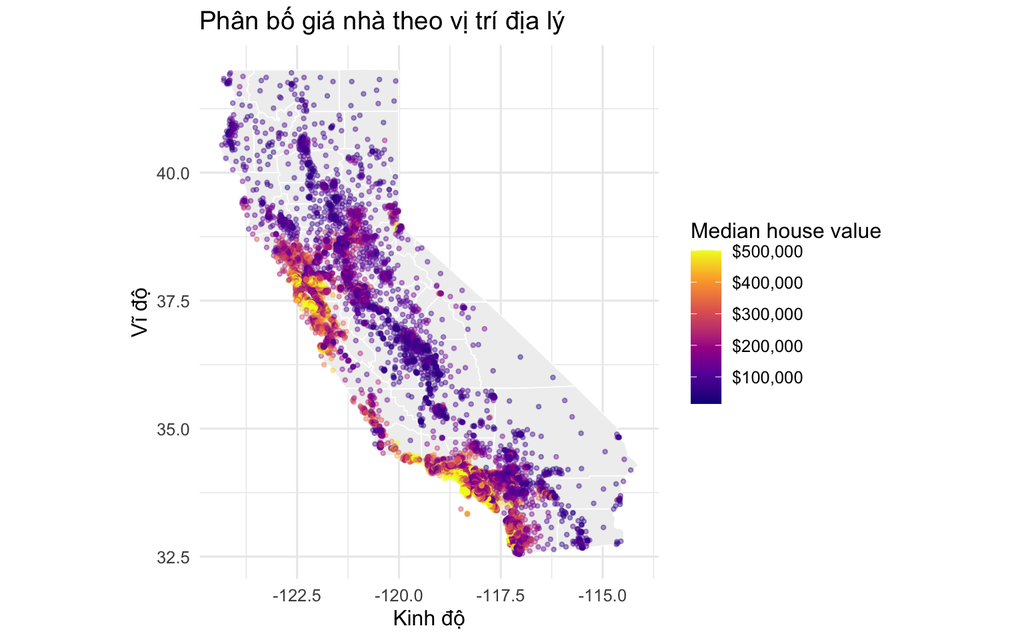

```r
ca_counties <- map_data("county", region = "california")

ggplot() +
  geom_polygon(
    data = ca_counties,
    aes(x = long, y = lat, group = group),
    fill = "#f0f0f0", color = "white", linewidth = 0.3
  ) +
  geom_point(
    data = housing,
    aes(x = longitude, y = latitude, color = median_house_value),
    alpha = 0.4, size = 0.8
  ) +
  scale_color_viridis_c(option = "plasma", labels = dollar_format()) +
  coord_quickmap() +
  labs(
    title = "Phân bố giá nhà theo vị trí địa lý",
    x = "Kinh độ",
    y = "Vĩ độ",
    color = "Median house value"
  )
```

Bản đồ cho thấy các tính chất vị trí rõ ràng: các khu vực ven biển (San Francisco Bay Area, Los Angeles, San Diego) có giá nhà cao nhất, trong khi Central Valley và khu vực nội địa có giá thấp hơn đáng kể. Điều này có thể gợi ý là các biến `longitude`, `latitude` và `ocean_proximity` đều cần được giữ trong model vì mỗi biến có thể ẩn chứa một khía cạnh khác nhau của vị trí địa lý và không thể thay thế cho nhau.

## 3.2 Kiểm tra dữ liệu thiếu

```r
missing_table <- data.frame(
  variable = names(housing),
  missing_count = colSums(is.na(housing)),
  missing_rate = colMeans(is.na(housing))
)

missing_table |>
  arrange(desc(missing_count)) |>
  mutate(missing_rate = percent(missing_rate, accuracy = 0.01)) |>
  kable(caption = "Số lượng và tỷ lệ giá trị thiếu theo biến")
```

Số lượng và tỷ lệ giá trị thiếu theo biến

|  | variable | missing_count | missing_rate |
| --- | --- | --- | --- |
| total_bedrooms | total_bedrooms | 207 | 1.00% |
| longitude | longitude | 0 | 0.00% |
| latitude | latitude | 0 | 0.00% |
| housing_median_age | housing_median_age | 0 | 0.00% |
| total_rooms | total_rooms | 0 | 0.00% |
| population | population | 0 | 0.00% |
| households | households | 0 | 0.00% |
| median_income | median_income | 0 | 0.00% |
| median_house_value | median_house_value | 0 | 0.00% |
| ocean_proximity | ocean_proximity | 0 | 0.00% |

Dữ liệu chỉ có giá trị thiếu ở biến `total_bedrooms`, với 207 quan sát, tương đương 1.00% toàn bộ dữ liệu. Vì tỷ lệ thiếu thấp, bước tiếp theo cần kiểm tra xem thiếu có tập trung theo một nhóm địa lý hay nhóm `ocean_proximity` cụ thể không. Nếu thiếu tập trung mạnh ở một nhóm, việc thay thế bằng median chung có thể làm mất đặc điểm riêng của nhóm đó; nếu thiếu rải rác và nhóm thiếu có đặc điểm tương đối gần nhóm không thiếu, median imputation là lựa chọn đơn giản và đủ ổn cho bài thực hành tuyến tính này.

```r
missing_by_ocean <- housing |>
  group_by(ocean_proximity) |>
  summarise(
    n = n(),
    missing_total_bedrooms = sum(is.na(total_bedrooms)),
    missing_rate = mean(is.na(total_bedrooms)),
    .groups = "drop"
  )

missing_by_ocean |>
  mutate(missing_rate = percent(missing_rate, accuracy = 0.01)) |>
  kable(caption = "Tỷ lệ thiếu total_bedrooms theo ocean_proximity")
```

Tỷ lệ thiếu total_bedrooms theo ocean_proximity

| ocean_proximity | n | missing_total_bedrooms | missing_rate |
| --- | --- | --- | --- |
| <1H OCEAN | 9136 | 102 | 1.12% |
| INLAND | 6551 | 55 | 0.84% |
| ISLAND | 5 | 0 | 0.00% |
| NEAR BAY | 2290 | 20 | 0.87% |
| NEAR OCEAN | 2658 | 30 | 1.13% |

```r
missing_pattern_summary <- housing |>
  mutate(
    total_bedrooms_status = ifelse(
      is.na(total_bedrooms),
      "Thiếu total_bedrooms",
      "Không thiếu total_bedrooms"
    )
  ) |>
  group_by(total_bedrooms_status) |>
  summarise(
    n = n(),
    median_income_median = median(median_income),
    median_house_value_median = median(median_house_value),
    total_rooms_median = median(total_rooms),
    population_median = median(population),
    households_median = median(households),
    .groups = "drop"
  )

missing_pattern_summary |>
  kable(
    digits = 2,
    caption = "So sánh nhanh nhóm thiếu và không thiếu total_bedrooms"
  )
```

So sánh nhanh nhóm thiếu và không thiếu total_bedrooms

| total_bedrooms_status | n | median_income_median | median_house_value_median | total_rooms_median | population_median | households_median |
| --- | --- | --- | --- | --- | --- | --- |
| Không thiếu total_bedrooms | 20433 | 3.54 | 179700 | 2127 | 1166 | 409 |
| Thiếu total_bedrooms | 207 | 3.41 | 175000 | 2155 | 1217 | 427 |

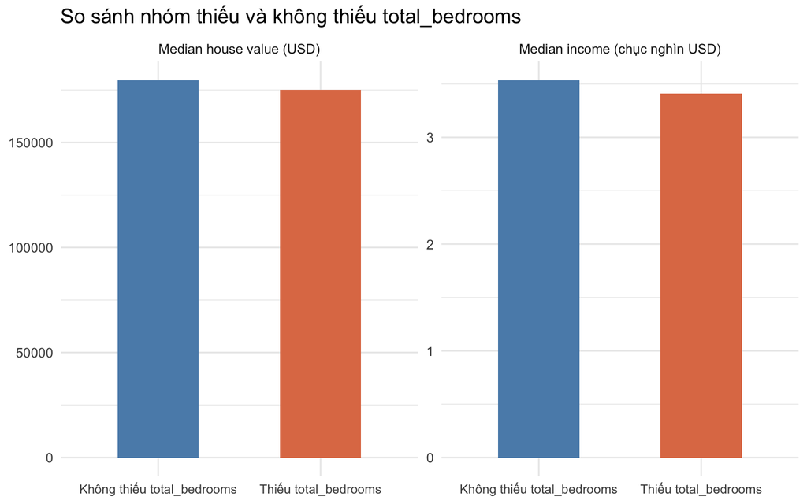

```r
missing_pattern_summary |>
  select(total_bedrooms_status, median_income_median, median_house_value_median) |>
  tidyr::pivot_longer(
    cols = c(median_income_median, median_house_value_median),
    names_to = "variable",
    values_to = "value"
  ) |>
  mutate(
    variable = case_match(variable,
      "median_income_median" ~ "Median income (chục nghìn USD)",
      "median_house_value_median" ~ "Median house value (USD)",
      .default = variable
    )
  ) |>
  ggplot(aes(x = total_bedrooms_status, y = value, fill = total_bedrooms_status)) +
  geom_col(width = 0.5, show.legend = FALSE) +
  facet_wrap(~variable, scales = "free_y") +
  scale_fill_manual(values = c("Thiếu total_bedrooms" = "#e07b54", "Không thiếu total_bedrooms" = "#5b8db8")) +
  labs(
    title = "So sánh nhóm thiếu và không thiếu total_bedrooms",
    x = NULL,
    y = NULL
  ) +
  theme(axis.text.x = element_text(size = 9))
```

Kết quả cho thấy thiếu dữ liệu không phải do toàn bộ một biến bị lỗi, mà chỉ xuất hiện ở `total_bedrooms`. Tỷ lệ thiếu theo các nhóm `ocean_proximity` đều thấp và không chỉ tập trung vào một nhóm lớn duy nhất; nhóm `ISLAND` không có giá trị thiếu nhưng chỉ có rất ít quan sát nên không đủ để kết luận riêng. So sánh nhóm thiếu và không thiếu cũng không cho thấy khác biệt cực đoan về thu nhập trung vị hay giá nhà trung vị. Vì vậy, trong phạm vi bài này, có thể xem cơ chế thiếu gần với thiếu ngẫu nhiên có điều kiện theo các đặc trưng quan sát được hơn là lỗi hệ thống rõ ràng. Tuy nhiên, không thể chứng minh dữ liệu là MCAR tuyệt đối chỉ từ bảng này.

Do đó, thay thế `total_bedrooms` thiếu bằng median là hợp lý vì: tỷ lệ thiếu thấp, median bền vững hơn mean khi các biến đếm như số phòng có đuôi phải dài, và median được tính trên tập training để tránh rò rỉ thông tin từ validation. Một cách cải thiện tốt hơn trong nghiên cứu sâu hơn là impute theo nhóm `ocean_proximity` hoặc dùng mô hình imputation dựa trên `total_rooms`, `households` và `population`.

## 3.3 Thống kê mô tả

```r
skewness <- function(x) {
  x <- x[!is.na(x)]
  mean((x - mean(x))^3) / sd(x)^3
}

numeric_summary <- housing |>
  select(where(is.numeric)) |>
  pivot_longer(everything(), names_to = "variable", values_to = "value") |>
  group_by(variable) |>
  summarise(
    n = sum(!is.na(value)),
    missing_count = sum(is.na(value)),
    mean = mean(value, na.rm = TRUE),
    sd = sd(value, na.rm = TRUE),
    min = min(value, na.rm = TRUE),
    q1 = quantile(value, 0.25, na.rm = TRUE),
    median = median(value, na.rm = TRUE),
    q3 = quantile(value, 0.75, na.rm = TRUE),
    max = max(value, na.rm = TRUE),
    iqr = IQR(value, na.rm = TRUE),
    skewness = skewness(value),
    .groups = "drop"
  )

numeric_summary |>
  kable(digits = 2, caption = "Thống kê mô tả các biến định lượng")
```

Thống kê mô tả các biến định lượng

| variable | n | missing_count | mean | sd | min | q1 | median | q3 | max | iqr | skewness |
| --- | --- | --- | --- | --- | --- | --- | --- | --- | --- | --- | --- |
| households | 20640 | 0 | 499.54 | 382.33 | 1.00 | 280.00 | 409.00 | 605.00 | 6082.00 | 325.00 | 3.41 |
| housing_median_age | 20640 | 0 | 28.64 | 12.59 | 1.00 | 18.00 | 29.00 | 37.00 | 52.00 | 19.00 | 0.06 |
| latitude | 20640 | 0 | 35.63 | 2.14 | 32.54 | 33.93 | 34.26 | 37.71 | 41.95 | 3.78 | 0.47 |
| longitude | 20640 | 0 | -119.57 | 2.00 | -124.35 | -121.80 | -118.49 | -118.01 | -114.31 | 3.79 | -0.30 |
| median_house_value | 20640 | 0 | 206855.82 | 115395.62 | 14999.00 | 119600.00 | 179700.00 | 264725.00 | 500001.00 | 145125.00 | 0.98 |
| median_income | 20640 | 0 | 3.87 | 1.90 | 0.50 | 2.56 | 3.53 | 4.74 | 15.00 | 2.18 | 1.65 |
| population | 20640 | 0 | 1425.48 | 1132.46 | 3.00 | 787.00 | 1166.00 | 1725.00 | 35682.00 | 938.00 | 4.94 |
| total_bedrooms | 20433 | 207 | 537.87 | 421.39 | 1.00 | 296.00 | 435.00 | 647.00 | 6445.00 | 351.00 | 3.46 |
| total_rooms | 20640 | 0 | 2635.76 | 2181.62 | 2.00 | 1447.75 | 2127.00 | 3148.00 | 39320.00 | 1700.25 | 4.15 |

```r
housing |>
  count(ocean_proximity, sort = TRUE) |>
  mutate(rate = percent(n / sum(n), accuracy = 0.01)) |>
  kable(caption = "Phân bố biến ocean_proximity")
```

Phân bố biến ocean_proximity

| ocean_proximity | n | rate |
| --- | --- | --- |
| <1H OCEAN | 9136 | 44.26% |
| INLAND | 6551 | 31.74% |
| NEAR OCEAN | 2658 | 12.88% |
| NEAR BAY | 2290 | 11.09% |
| ISLAND | 5 | 0.02% |

`ocean_proximity` là biến phân loại mô tả vị trí tương đối của census block group so với biển hoặc vịnh. Các mức chính gồm:

- `<1H OCEAN`: khu vực cách biển dưới khoảng một giờ di chuyển.
- `INLAND`: khu vực sâu trong đất liền.
- `NEAR BAY`: khu vực gần vịnh.
- `NEAR OCEAN`: khu vực gần biển.
- `ISLAND`: khu vực đảo.

Biến này quan trọng vì vị trí ven biển hoặc gần vịnh thường gắn với khả năng tiếp cận việc làm, tiện ích, khí hậu, mật độ đô thị và mức khan hiếm đất khác với khu vực sâu trong đất liền. Do đó, `ocean_proximity` không chỉ là nhãn địa lý mà còn là proxy cho nhiều yếu tố kinh tế - xã hội ảnh hưởng đến giá nhà. Phân bố của biến này cũng không cân bằng: nhóm `<1H OCEAN` và `INLAND` chiếm phần lớn dữ liệu, trong khi `ISLAND` chỉ có rất ít quan sát. Vì vậy, hệ số hoặc kết luận riêng cho `ISLAND` cần được diễn giải rất thận trọng; mô hình có thể học kém cho nhóm hiếm này.

Từ bảng thống kê mô tả, nhiều biến đếm như `total_rooms`, `total_bedrooms`, `population` và `households` có khoảng cách lớn giữa median và max, cho thấy phân phối lệch phải và có các khu vực rất lớn. Vì các biến này là tổng theo khu vực chứ không phải đặc điểm của một căn nhà riêng lẻ, diễn giải trực tiếp hệ số của chúng cần cẩn trọng. Các biến tỷ lệ được tạo thêm ở phần tiền xử lý như `rooms_per_household`, `bedrooms_per_room` và `population_per_household` giúp chuyển thông tin tổng hợp này thành đặc điểm dễ so sánh hơn giữa các khu vực.

## 3.4 Phân phối các biến numeric

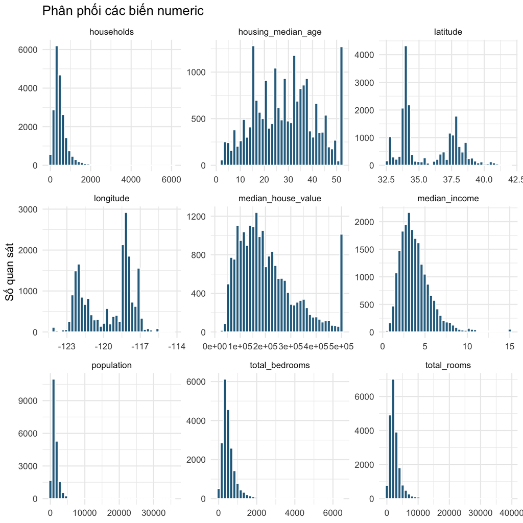

```r
housing |>
  select(where(is.numeric)) |>
  pivot_longer(everything(), names_to = "variable", values_to = "value") |>
  ggplot(aes(x = value)) +
  geom_histogram(bins = 40, fill = "#2F6F8F", color = "white") +
  facet_wrap(~variable, scales = "free") +
  labs(
    title = "Phân phối các biến numeric",
    x = NULL,
    y = "Số quan sát"
  )
```

Các biến đếm `total_rooms`, `total_bedrooms`, `population` và `households` có phân phối lệch phải mạnh với đuôi dài. Đây là cơ sở để tạo thêm ratio variables bên cạnh raw counts, giúp mô hình có thêm các đặc trưng dễ so sánh hơn giữa các khu vực, và lý giải tại sao log-transform có thể giúp tuyến tính hóa một số mối quan hệ giữa biến dự báo và biến mục tiêu.

## 3.5 Phân tích outlier

```r
outlier_summary <- housing |>
  select(where(is.numeric)) |>
  pivot_longer(everything(), names_to = "variable", values_to = "value") |>
  group_by(variable) |>
  summarise(
    q1 = quantile(value, 0.25, na.rm = TRUE),
    q3 = quantile(value, 0.75, na.rm = TRUE),
    iqr = IQR(value, na.rm = TRUE),
    fence_upper = q3 + 3 * iqr,
    n_extreme = sum(value > q3 + 3 * iqr, na.rm = TRUE),
    pct_extreme = mean(value > q3 + 3 * iqr, na.rm = TRUE),
    .groups = "drop"
  ) |>
  arrange(desc(n_extreme))

outlier_summary |>
  select(variable, fence_upper, n_extreme, pct_extreme) |>
  mutate(pct_extreme = percent(pct_extreme, accuracy = 0.01)) |>
  kable(
    digits = 1,
    col.names = c("Biến", "Ngưỡng Q3+3*IQR", "Số quan sát vượt ngưỡng", "Tỷ lệ"),
    caption = "Phân tích extreme outlier theo ngưỡng Q3 + 3×IQR"
  )
```

Phân tích extreme outlier theo ngưỡng Q3 + 3×IQR

| Biến | Ngưỡng Q3+3*IQR | Số quan sát vượt ngưỡng | Tỷ lệ |
| --- | --- | --- | --- |
| total_rooms | 8248.8 | 494 | 2.39% |
| total_bedrooms | 1700.0 | 443 | 2.17% |
| population | 4539.0 | 421 | 2.04% |
| households | 1580.0 | 415 | 2.01% |
| median_income | 11.3 | 140 | 0.68% |
| housing_median_age | 94.0 | 0 | 0.00% |
| latitude | 49.1 | 0 | 0.00% |
| longitude | -106.6 | 0 | 0.00% |
| median_house_value | 700100.0 | 0 | 0.00% |

Các biến đếm (`total_rooms`, `population`, `households`) có số outlier đáng kể. Tuy nhiên, đây là dữ liệu thực tế của các khu vực dân cư, không phải lỗi nhập liệu nên giữ nguyên thay vì loại bỏ. Lưu ý rằng OLS nhạy cảm với outlier vì dùng hàm MSE; đây là thêm một lý do để quan tâm đến các ratio variables thay vì raw counts.

## 3.6 Log-linearity check

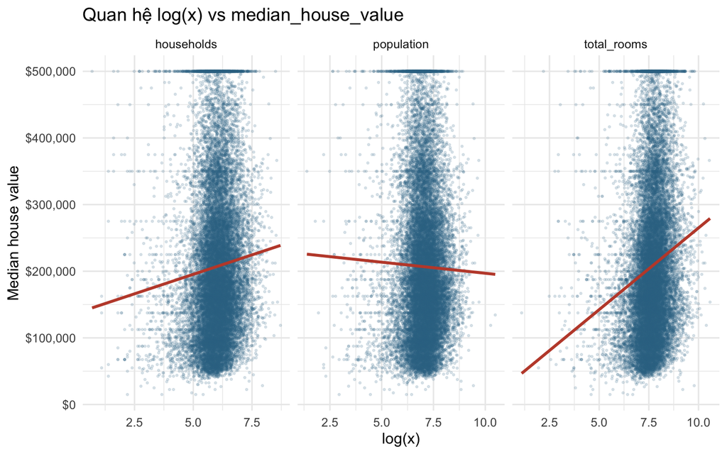

```r
housing |>
  select(total_rooms, population, households, median_house_value) |>
  pivot_longer(-median_house_value, names_to = "variable", values_to = "value") |>
  mutate(log_value = log(value + 1)) |>
  ggplot(aes(x = log_value, y = median_house_value)) +
  geom_point(alpha = 0.15, size = 0.5, color = "#2F6F8F") +
  geom_smooth(method = "lm", se = FALSE, color = "#C04B37") +
  facet_wrap(~variable, scales = "free_x") +
  scale_y_continuous(labels = dollar_format()) +
  labs(
    title = "Quan hệ log(x) vs median_house_value",
    x = "log(x)",
    y = "Median house value"
  )
```

Khi dùng thang logarithm, mối quan hệ giữa các biến đếm và giá nhà có xu hướng tuyến tính hơn so với thang gốc. Điều này gợi ý rằng các raw count variables có quan hệ phi tuyến với giá nhà; ratio variables (như `rooms_per_household`) là một hướng feature engineering bổ sung để chuyển thông tin quy mô khu vực thành đặc trưng dễ so sánh hơn giữa các khu vực.

## 3.7 Phân phối biến mục tiêu

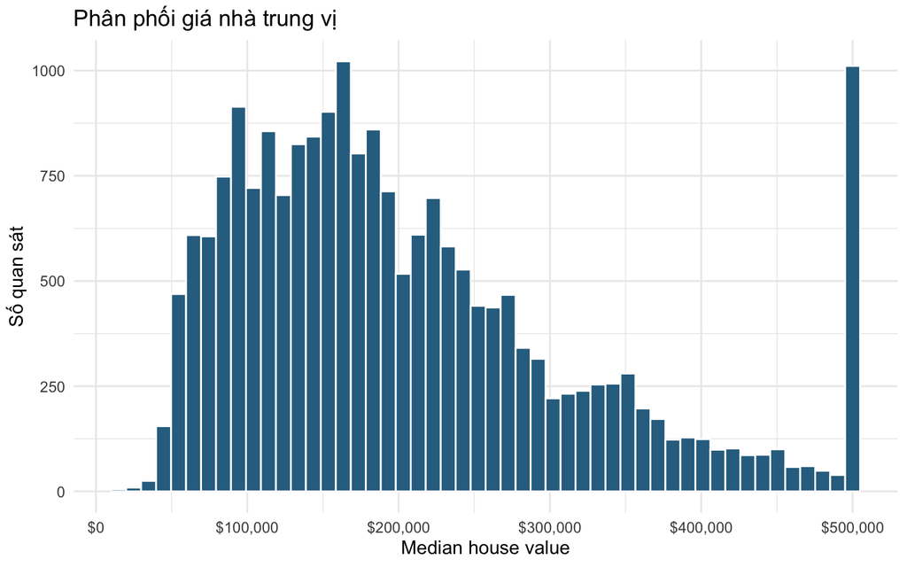

```r
ggplot(housing, aes(x = median_house_value)) +
  geom_histogram(bins = 50, fill = "#2F6F8F", color = "white") +
  scale_x_continuous(labels = dollar_format()) +
  labs(
    title = "Phân phối giá nhà trung vị",
    x = "Median house value",
    y = "Số quan sát"
  )
```

```r
target_summary <- data.frame(
  min = min(housing$median_house_value),
  q1 = quantile(housing$median_house_value, 0.25),
  median = median(housing$median_house_value),
  mean = mean(housing$median_house_value),
  q3 = quantile(housing$median_house_value, 0.75),
  max = max(housing$median_house_value),
  capped_count = sum(housing$median_house_value == max(housing$median_house_value)),
  capped_rate = mean(housing$median_house_value == max(housing$median_house_value)),
  skewness = skewness(housing$median_house_value)
)

target_summary |>
  mutate(capped_rate = percent(capped_rate, accuracy = 0.01)) |>
  kable(digits = 2, caption = "Tóm tắt phân phối median_house_value")
```

Tóm tắt phân phối median_house_value

|  | min | q1 | median | mean | q3 | max | capped_count | capped_rate | skewness |
| --- | --- | --- | --- | --- | --- | --- | --- | --- | --- |
| 25% | 14999 | 119600 | 179700 | 206855.8 | 264725 | 500001 | 965 | 4.68% | 0.98 |

Biến mục tiêu `median_house_value` bị lệch phải và có giá trị lớn nhất bằng $500,001. Có 965 quan sát nằm đúng tại giá trị lớn nhất này, tương đương 4.68% dữ liệu. Đây là dấu hiệu dữ liệu bị chặn trên: các khu vực có giá trị thực tế cao hơn ngưỡng này vẫn được ghi nhận cùng một giá trị.

Đây là một vấn đề quan trọng cho cả dự báo và diễn giải. Với mô hình hồi quy tuyến tính dùng MSE/RMSE, các quan sát giá cao có ảnh hưởng lớn đến hàm mất mát, nhưng do phần đỉnh bị gộp tại `500001`, mô hình khó học được khác biệt thật giữa các khu vực rất đắt. Vì vậy, sai số ở phân khúc cao có thể bị diễn giải sai: dự đoán thấp hơn `500001` không nhất thiết chỉ là mô hình kém, mà còn phản ánh việc nhãn mục tiêu đã bị kiểm duyệt/capping. Khi diễn giải hệ số, cần hiểu rằng tác động của các biến như `median_income` hoặc vị trí gần biển lên giá nhà cao cấp có thể bị đánh giá thấp vì biến mục tiêu không còn tăng sau ngưỡng này.

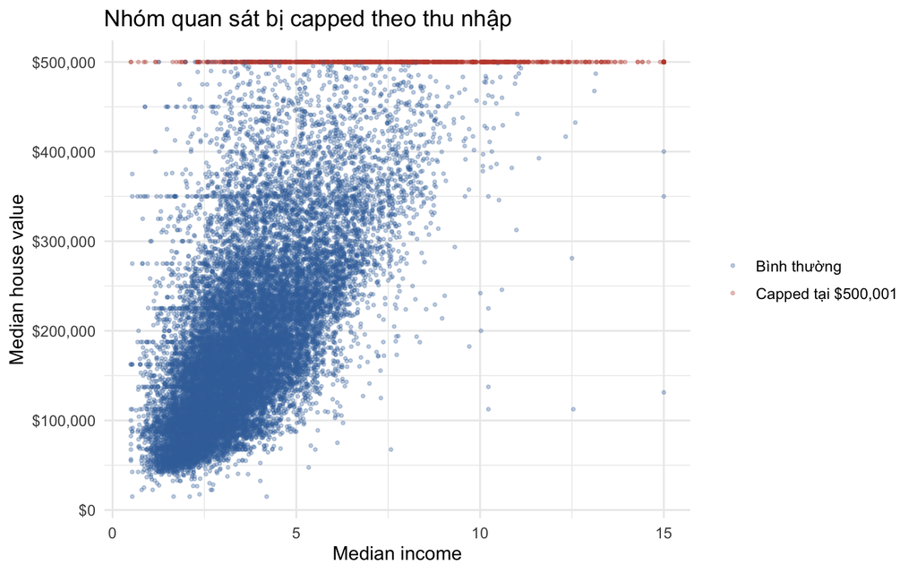

```r
housing |>
  mutate(is_capped = median_house_value == max(median_house_value)) |>
  ggplot(aes(x = median_income, y = median_house_value, color = is_capped)) +
  geom_point(alpha = 0.3, size = 0.7) +
  scale_y_continuous(labels = dollar_format()) +
  scale_color_manual(
    values = c("FALSE" = "#3B6EA8", "TRUE" = "#C04B37"),
    labels = c("FALSE" = "Bình thường", "TRUE" = "Capped tại $500,001")
  ) +
  labs(
    title = "Nhóm quan sát bị capped theo thu nhập",
    x = "Median income",
    y = "Median house value",
    color = NULL
  )
```

Nhóm bị chặn trên (đường màu đỏ) có `median_income` trải rộng từ thấp đến cao, không chỉ tập trung ở nhóm thu nhập cao. Điều này cho thấy capping không chỉ ảnh hưởng đến các khu vực giàu nhất mà còn tạo ra “trần nhân tạo” không phản ánh thực tế thị trường, khiến model khó phân biệt được các khu vực rất đắt với nhau.

## 3.8 Thu nhập và giá nhà

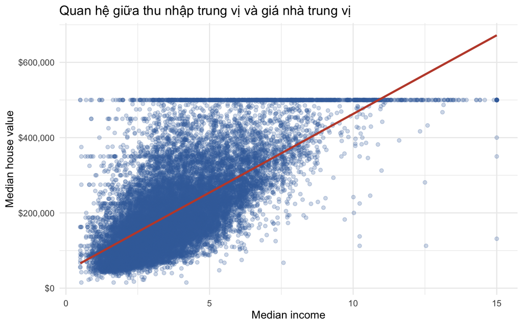

```r
ggplot(housing, aes(x = median_income, y = median_house_value)) +
  geom_point(alpha = 0.25, color = "#3B6EA8") +
  geom_smooth(method = "lm", se = FALSE, color = "#C04B37") +
  scale_y_continuous(labels = dollar_format()) +
  labs(
    title = "Quan hệ giữa thu nhập trung vị và giá nhà trung vị",
    x = "Median income",
    y = "Median house value"
  )
```

`median_income` có xu hướng tương quan dương rõ rệt với `median_house_value`. Đây thường là một trong những biến dự báo quan trọng nhất của giá nhà.

## 3.9 Giá nhà theo vị trí so với biển

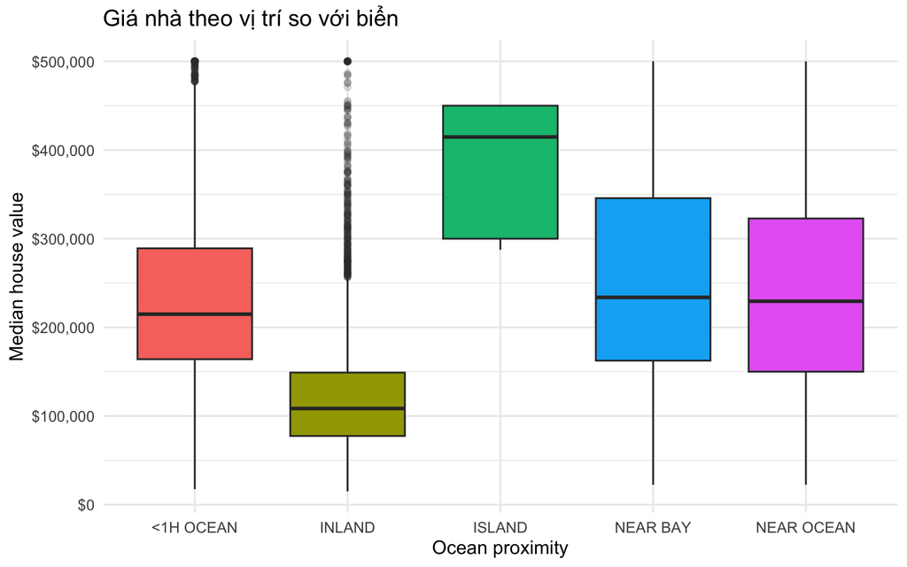

```r
ggplot(housing, aes(x = ocean_proximity, y = median_house_value, fill = ocean_proximity)) +
  geom_boxplot(outlier.alpha = 0.15) +
  scale_y_continuous(labels = dollar_format()) +
  guides(fill = "none") +
  labs(
    title = "Giá nhà theo vị trí so với biển",
    x = "Ocean proximity",
    y = "Median house value"
  )
```

Các khu vực gần biển hoặc gần vịnh có xu hướng giá nhà cao hơn khu vực `INLAND`.

## 3.10 Tương quan giữa các biến định lượng

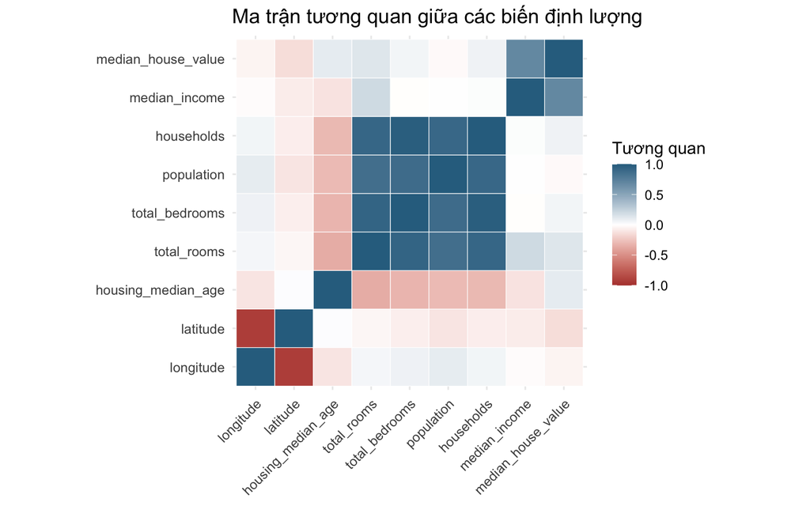

```r
cor_data <- housing |>
  select(where(is.numeric)) |>
  cor(use = "pairwise.complete.obs")

cor_long <- as.data.frame(as.table(cor_data))
names(cor_long) <- c("var1", "var2", "correlation")

ggplot(cor_long, aes(x = var1, y = var2, fill = correlation)) +
  geom_tile(color = "white") +
  scale_fill_gradient2(
    low = "#B4433C",
    mid = "white",
    high = "#2F6F8F",
    midpoint = 0,
    limits = c(-1, 1)
  ) +
  coord_equal() +
  labs(
    title = "Ma trận tương quan giữa các biến định lượng",
    x = NULL,
    y = NULL,
    fill = "Tương quan"
  ) +
  theme(axis.text.x = element_text(angle = 45, hjust = 1))
```

## 3.11 Đa cộng tuyến sơ bộ giữa các biến đếm

```r
count_vars <- c("total_rooms", "total_bedrooms", "population", "households")

cor_counts <- housing |>
  select(all_of(count_vars)) |>
  cor(use = "pairwise.complete.obs")

cor_counts |>
  round(3) |>
  kable(caption = "Ma trận tương quan: 4 biến đếm cấp khu vực")
```

Ma trận tương quan: 4 biến đếm cấp khu vực

|  | total_rooms | total_bedrooms | population | households |
| --- | --- | --- | --- | --- |
| total_rooms | 1.000 | 0.930 | 0.857 | 0.918 |
| total_bedrooms | 0.930 | 1.000 | 0.878 | 0.980 |
| population | 0.857 | 0.878 | 1.000 | 0.907 |
| households | 0.918 | 0.980 | 0.907 | 1.000 |

# 4 Tổng kết EDA & Thách thức chính

Qua khám phá dữ liệu, hai vấn đề nổi bật cần lưu ý trước khi xây dựng mô hình:

1. **Biến mục tiêu bị chặn trên ở `500,001` (~4.7% quan sát).** Histogram của `median_house_value` cho thấy một spike rõ ràng tại ngưỡng này: các khu vực có giá trị thực cao hơn vẫn được gán cùng nhãn, làm méo residuals ở phân khúc giá cao và khiến mô hình có xu hướng underpredict những khu vực đắt nhất.
2. **Dữ liệu không gian có spatial clustering rõ ràng.** Bản đồ địa lý cho thấy giá nhà phân bố thành các cụm địa lý rõ ràng (ven biển cao hơn nội địa, khu vực vịnh San Francisco và Los Angeles tập trung giá cao), gợi ý khả năng có spatial autocorrelation. Mô hình tuyến tính với `longitude` và `latitude` như các biến độc lập khó capture đầy đủ cấu trúc phi tuyến này.

**Scope:** Bài giới hạn ở nhóm linear models (OLS, Ridge, LASSO, Elastic Net). So sánh với các mô hình phi tuyến như Random Forest hay Gradient Boosting, vốn xử lý tốt hơn hai vấn đề trên, nằm ngoài phạm vi bài thực hành này.

# 5 Tiền xử lý dữ liệu

## 5.1 Chia training và validation

```r
n <- nrow(housing)
train_id <- sample(seq_len(n), size = floor(0.8 * n))

train_raw <- housing[train_id, ]
valid_raw <- housing[-train_id, ]

c(
  training_size = nrow(train_raw),
  validation_size = nrow(valid_raw)
)
```

```
##   training_size validation_size
##           16512            4128
```

Tỷ lệ 80/20 phù hợp với dataset ~20,000 rows: tập validation ~4,100 rows đủ lớn để ước lượng RMSE ổn định mà không lãng phí quá nhiều dữ liệu training. Với dataset nhỏ hơn, có thể cân nhắc k-fold CV thay cho held-out validation.

## 5.2 Impute missing values và tạo biến mới

```r
bedrooms_median_train <- median(train_raw$total_bedrooms, na.rm = TRUE)

prepare_data <- function(data, bedrooms_median) {
  data |>
    mutate(
      total_bedrooms = ifelse(
        is.na(total_bedrooms),
        bedrooms_median,
        total_bedrooms
      ),
      ocean_proximity = factor(ocean_proximity),
      rooms_per_household = total_rooms / households,
      bedrooms_per_room = total_bedrooms / total_rooms,
      population_per_household = population / households,
      log_house_value = log(median_house_value)
    )
}

train <- prepare_data(train_raw, bedrooms_median_train)
valid <- prepare_data(valid_raw, bedrooms_median_train)

colSums(is.na(train))
```

```
##                longitude                 latitude       housing_median_age
##                        0                        0                        0
##              total_rooms           total_bedrooms               population
##                        0                        0                        0
##               households            median_income       median_house_value
##                        0                        0                        0
##          ocean_proximity      rooms_per_household        bedrooms_per_room
##                        0                        0                        0
## population_per_household          log_house_value
##                        0                        0
```

```r
colSums(is.na(valid))
```

```
##                longitude                 latitude       housing_median_age
##                        0                        0                        0
##              total_rooms           total_bedrooms               population
##                        0                        0                        0
##               households            median_income       median_house_value
##                        0                        0                        0
##          ocean_proximity      rooms_per_household        bedrooms_per_room
##                        0                        0                        0
## population_per_household          log_house_value
##                        0                        0
```

Ba biến mới được tạo để phản ánh cấu trúc khu vực tốt hơn:

- `rooms_per_household`: số phòng trung bình trên mỗi hộ.
- `bedrooms_per_room`: tỷ lệ phòng ngủ trên tổng số phòng.
- `population_per_household`: số người trung bình trên mỗi hộ.

## 5.3 Tạo ma trận thiết kế cho mô hình

```r
# Raw count features được giữ nguyên trong formula cùng ratio variables
# để VIF table ở Section 5 cho thấy mức độ đa cộng tuyến thực tế.
model_formula <- median_house_value ~ longitude + latitude +
  housing_median_age + total_rooms + total_bedrooms + population +
  households + median_income + ocean_proximity +
  rooms_per_household + bedrooms_per_room + population_per_household

x_train <- model.matrix(model_formula, data = train)[, -1]
x_valid <- model.matrix(model_formula, data = valid)[, -1]

y_train <- train$median_house_value
y_valid <- valid$median_house_value

dim(x_train)
```

```
## [1] 16512    15
```

```r
dim(x_valid)
```

```
## [1] 4128   15
```

# 6 Xây dựng mô hình

## 6.1 Hàm đánh giá mô hình

```r
calculate_metrics <- function(actual, predicted) {
  residual <- actual - predicted
  data.frame(
    RMSE = sqrt(mean(residual^2)),
    MAE = mean(abs(residual)),
    MAPE = mean(abs(residual / actual)) * 100,
    R2 = 1 - sum(residual^2) / sum((actual - mean(actual))^2)
  )
}

coef_to_table <- function(model, s = "lambda.min") {
  coef_matrix <- as.matrix(coef(model, s = s))
  data.frame(
    variable = rownames(coef_matrix),
    coefficient = as.numeric(coef_matrix[, 1]),
    row.names = NULL
  ) |>
    filter(variable != "(Intercept)", coefficient != 0) |>
    mutate(abs_coefficient = abs(coefficient)) |>
    arrange(desc(abs_coefficient))
}
```

## 6.2 Hồi quy tuyến tính bội ước lượng bằng OLS

```r
ols_model <- lm(model_formula, data = train)
ols_pred <- predict(ols_model, newdata = valid)

ols_metrics <- calculate_metrics(y_valid, ols_pred) |>
  mutate(model = "Hồi quy tuyến tính bội (OLS)", .before = 1)
```

```r
tidy(ols_model) |>
  arrange(desc(abs(estimate))) |>
  head(15) |>
  kable(digits = 4, caption = "15 hệ số của hồi quy tuyến tính bội (OLS) có độ lớn tuyệt đối cao nhất")
```

15 hệ số của hồi quy tuyến tính bội (OLS) có độ lớn tuyệt đối cao nhất

| term | estimate | std.error | statistic | p.value |
| --- | --- | --- | --- | --- |
| (Intercept) | -2403022.1748 | 98268.7478 | -24.4536 | 0.0000 |
| ocean_proximityISLAND | 171272.7432 | 34301.3538 | 4.9932 | 0.0000 |
| bedrooms_per_room | 152700.4609 | 12243.1202 | 12.4723 | 0.0000 |
| median_income | 39351.3558 | 396.4946 | 99.2481 | 0.0000 |
| ocean_proximityINLAND | -36520.4779 | 1941.4895 | -18.8105 | 0.0000 |
| longitude | -27828.0276 | 1137.1124 | -24.4725 | 0.0000 |
| latitude | -26469.3852 | 1122.7020 | -23.5765 | 0.0000 |
| ocean_proximityNEAR OCEAN | 5187.8698 | 1731.4868 | 2.9962 | 0.0027 |
| ocean_proximityNEAR BAY | -3930.0999 | 2120.2070 | -1.8536 | 0.0638 |
| rooms_per_household | 2414.7257 | 257.8429 | 9.3651 | 0.0000 |
| housing_median_age | 1043.2993 | 48.7713 | 21.3917 | 0.0000 |
| households | 115.2015 | 7.9838 | 14.4293 | 0.0000 |
| population_per_household | 60.8566 | 51.8510 | 1.1737 | 0.2405 |
| population | -39.0154 | 1.2328 | -31.6473 | 0.0000 |
| total_bedrooms | 15.4638 | 7.4390 | 2.0787 | 0.0377 |

```r
glance(ols_model) |>
  select(r.squared, adj.r.squared, statistic, p.value, df, df.residual, sigma) |>
  mutate(
    r.squared     = round(r.squared, 4),
    adj.r.squared = round(adj.r.squared, 4),
    statistic     = round(statistic, 2),
    p.value       = format.pval(p.value, digits = 3),
    sigma         = round(sigma, 2)
  ) |>
  kable(
    col.names = c("R²", "Adjusted R²", "F-statistic", "p-value (F)", "df model", "df residual", "Sigma"),
    caption   = "Thống kê tổng thể mô hình hồi quy tuyến tính bội (OLS)"
  )
```

Thống kê tổng thể mô hình hồi quy tuyến tính bội (OLS)

| R² | Adjusted R² | F-statistic | p-value (F) | df model | df residual | Sigma |
| --- | --- | --- | --- | --- | --- | --- |
| 0.6474 | 0.647 | 2018.8 | <2e-16 | 15 | 16496 | 68513.88 |

## 6.3 Diagnostics cho hồi quy tuyến tính bội (OLS)

Bốn tính chất cơ bản của mô hình hồi quy tuyến tính (linearity, independence, normality, homoscedasticity, viết tắt LINE) được kiểm tra qua đồ thị và kiểm định thống kê.

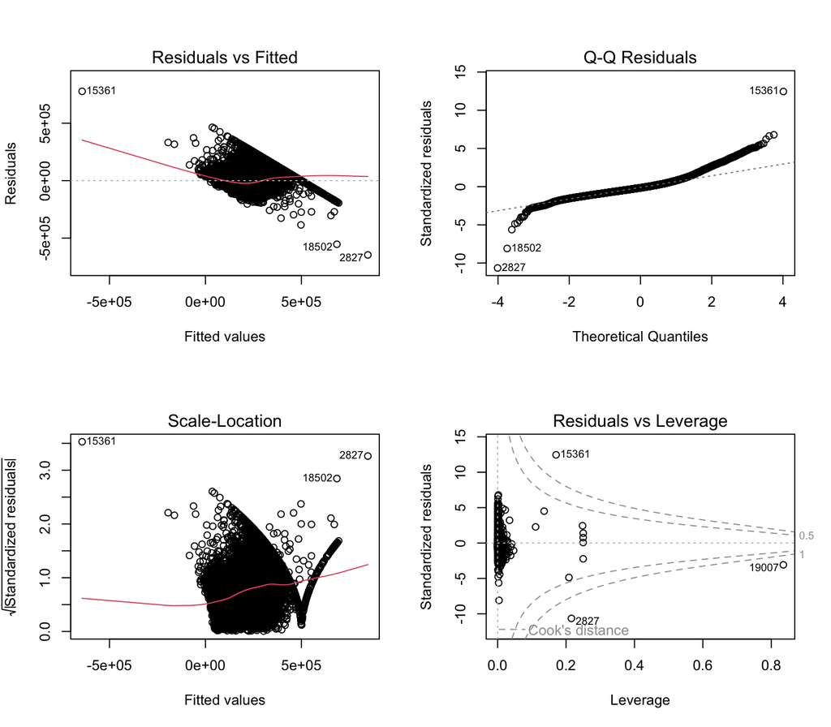

```r
par(mfrow = c(2, 2))
plot(ols_model)
```

```r
par(mfrow = c(1, 1))
```

```r
bp_test <- bptest(ols_model)
dw_test <- dwtest(ols_model, alternative = "two.sided")
reset_test <- resettest(ols_model, power = 2:3, type = "fitted")

res <- residuals(ols_model)
n_res <- length(res)
skew_res <- (sum((res - mean(res))^3) / n_res) / (sum((res - mean(res))^2) / n_res)^1.5
kurt_res <- (sum((res - mean(res))^4) / n_res) / (sum((res - mean(res))^2) / n_res)^2 - 3

assumption_summary <- data.frame(
  `Tính chất` = c("Tuyến tính", "Độc lập phần dư", "Chuẩn của phần dư", "Đồng nhất phương sai"),
  `Kiểm định` = c("RESET test", "Durbin-Watson", "Skewness / Kurtosis (n quá lớn cho Shapiro-Wilk)", "Breusch-Pagan"),
  `Thống kê` = c(
    paste0("F = ", round(reset_test$statistic, 3), ", p = ", format.pval(reset_test$p.value, digits = 3)),
    paste0("DW = ", round(dw_test$statistic, 3), ", p = ", format.pval(dw_test$p.value, digits = 3)),
    paste0("Skewness = ", round(skew_res, 3), ", Excess kurtosis = ", round(kurt_res, 3)),
    paste0("BP = ", round(bp_test$statistic, 3), ", p = ", format.pval(bp_test$p.value, digits = 3))
  ),
  `Kết luận` = c(
    ifelse(reset_test$p.value < 0.05, "Vi phạm tuyến tính (p < 0.05)", "Không bác bỏ tuyến tính"),
    ifelse(dw_test$p.value < 0.05, "Có tương quan chuỗi (p < 0.05)", "Không bác bỏ độc lập"),
    ifelse(abs(skew_res) > 1 | abs(kurt_res) > 3, "Phân phối lệch đáng kể", "Gần chuẩn"),
    ifelse(bp_test$p.value < 0.05, "Heteroscedasticity (p < 0.05)", "Không bác bỏ đồng nhất phương sai")
  ),
  check.names = FALSE
)

assumption_summary |>
  kable(caption = "Kiểm định 4 tính chất cơ bản của hồi quy tuyến tính bội (OLS)")
```

Kiểm định 4 tính chất cơ bản của hồi quy tuyến tính bội (OLS)

| Tính chất | Kiểm định | Thống kê | Kết luận |
| --- | --- | --- | --- |
| Tuyến tính | RESET test | F = 533.076, p = <2e-16 | Vi phạm tuyến tính (p < 0.05) |
| Độc lập phần dư | Durbin-Watson | DW = 1.976, p = 0.119 | Không bác bỏ độc lập |
| Chuẩn của phần dư | Skewness / Kurtosis (n quá lớn cho Shapiro-Wilk) | Skewness = 1.158, Excess kurtosis = 4.759 | Phân phối lệch đáng kể |
| Đồng nhất phương sai | Breusch-Pagan | BP = 1246.364, p = <2e-16 | Heteroscedasticity (p < 0.05) |

**Linearity (tuyến tính):** RESET test kiểm tra xem thêm bậc cao của fitted values (bình phương, lập phương) có cải thiện đáng kể mô hình không. Nếu có (p < 0.05), mối quan hệ giữa features và y không hoàn toàn tuyến tính. Đồ thị Residuals vs Fitted cũng cho thấy pattern ở vùng giá cao.

**Independence (độc lập phần dư):** Durbin-Watson test kiểm tra tương quan bậc 1 của phần dư theo thứ tự quan sát. Với dữ liệu cross-sectional, đây chỉ là kiểm tra sơ bộ về sự phụ thuộc tuần tự trong dữ liệu đã sắp xếp, không phải kiểm định spatial autocorrelation chuẩn. Nếu muốn kiểm tra phụ thuộc không gian một cách trực tiếp hơn, cần dùng các kiểm định như Moran’s I trên phần dư.

**Normality (chuẩn của phần dư):** Shapiro-Wilk không áp dụng được khi n > 5,000 (luôn reject vì power quá cao). Thay vào đó dùng skewness và excess kurtosis của phần dư để đánh giá mức độ lệch so với phân phối chuẩn (chuẩn lý tưởng: skewness = 0, excess kurtosis = 0). QQ-plot trực quan hóa đuôi phân phối.

**Homoscedasticity (đồng nhất phương sai):** Breusch-Pagan test kiểm tra xem phương sai của phần dư có phụ thuộc vào fitted values không. Heteroscedasticity làm standard errors thông thường của OLS có thể bị sai, khiến p-values và confidence intervals của hệ số kém tin cậy hơn.

## 6.4 Kiểm tra tuyến tính từng biến

Kết quả RESET test cho biết mô hình tổng thể có vi phạm tuyến tính hay không, nhưng không chỉ ra biến nào gây ra vấn đề. Component-plus-Residual plots (`crPlots`) giải quyết điểm này: mỗi panel vẽ một predictor, so sánh quan hệ tuyến tính mà OLS đang giả định (đường thẳng) với quan hệ thực tế trong dữ liệu (đường cong loess). Nếu hai đường khớp nhau thì giả định tuyến tính với biến đó là hợp lý; nếu lệch rõ thì biến đó cần được transform (ví dụ log) hoặc thêm bậc cao trước khi đưa vào mô hình.

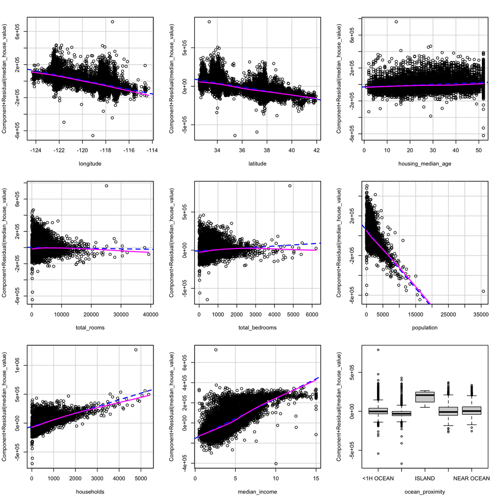

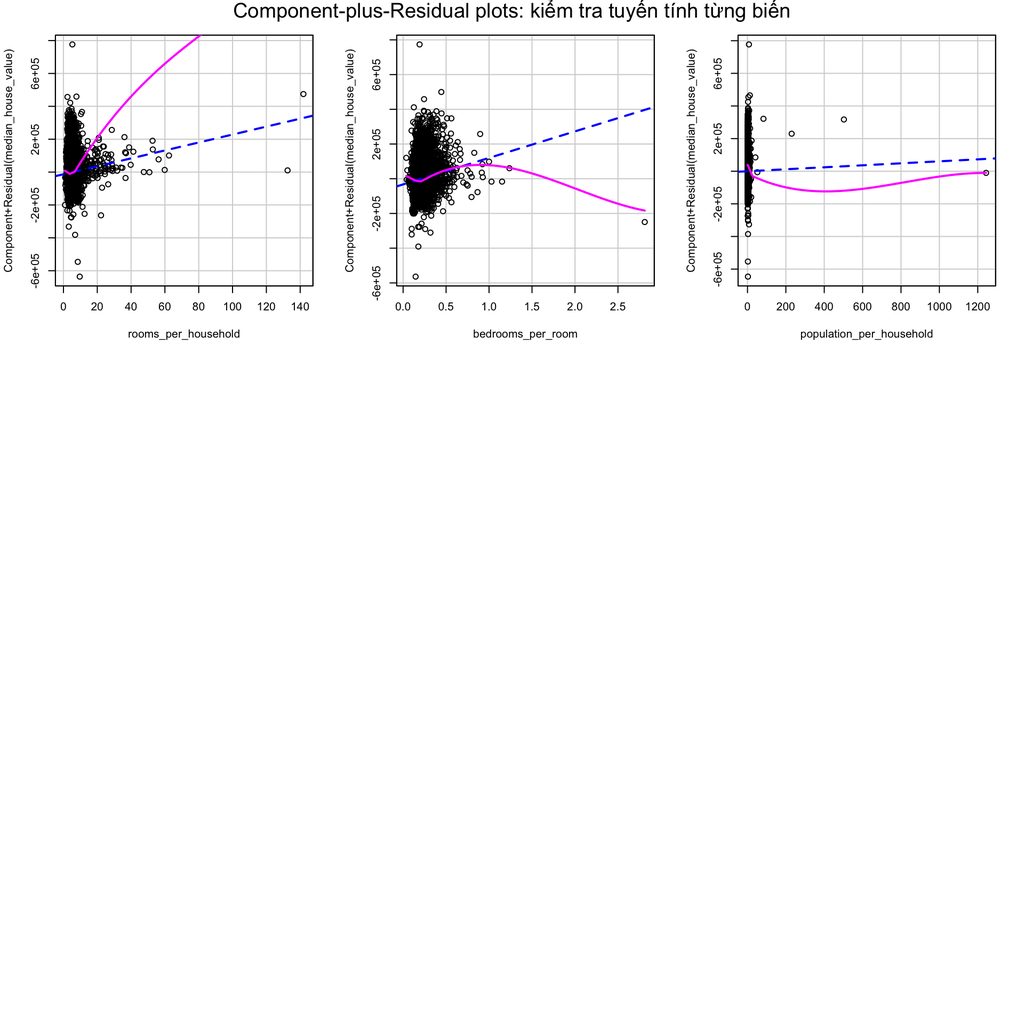

```r
crPlots(ols_model,
  smooth = TRUE, ask = FALSE,
  main = "Component-plus-Residual plots: kiểm tra tuyến tính từng biến"
)
```

## 6.5 VIF: Kiểm tra đa cộng tuyến trong hồi quy tuyến tính bội (OLS)

```r
vif_raw <- vif(ols_model)

# vif() trả về matrix (GVIF, Df, GVIF^(1/(2*Df))) khi có biến phân loại.
# Dùng adjusted GVIF để so sánh, và bình phương nó để có VIF-equivalent.
if (is.matrix(vif_raw)) {
  vif_df <- data.frame(
    variable = rownames(vif_raw),
    VIF_adjusted = vif_raw[, "GVIF^(1/(2*Df))"],
    VIF_equivalent = vif_raw[, "GVIF^(1/(2*Df))"]^2,
    row.names = NULL
  )
} else {
  vif_equivalent <- as.numeric(vif_raw)
  vif_df <- data.frame(
    variable = names(vif_raw),
    VIF_adjusted = sqrt(vif_equivalent),
    VIF_equivalent = vif_equivalent,
    row.names = NULL
  )
}

vif_df |>
  arrange(desc(VIF_equivalent)) |>
  mutate(
    severity = case_when(
      VIF_equivalent > 10 ~ "Cao (>10), đa cộng tuyến nghiêm trọng",
      VIF_equivalent > 5 ~ "Trung bình (5-10), cần chú ý",
      TRUE ~ "Chấp nhận được (<5)"
    )
  ) |>
  kable(digits = 2, caption = "Adjusted GVIF và VIF-equivalent trong hồi quy tuyến tính bội (OLS)")
```

Adjusted GVIF và VIF-equivalent trong hồi quy tuyến tính bội (OLS)

| variable | VIF_adjusted | VIF_equivalent | severity |
| --- | --- | --- | --- |
| total_bedrooms | 5.82 | 33.92 | Cao (>10), đa cộng tuyến nghiêm trọng |
| households | 5.70 | 32.49 | Cao (>10), đa cộng tuyến nghiêm trọng |
| latitude | 4.51 | 20.37 | Cao (>10), đa cộng tuyến nghiêm trọng |
| longitude | 4.28 | 18.35 | Cao (>10), đa cộng tuyến nghiêm trọng |
| total_rooms | 4.06 | 16.45 | Cao (>10), đa cộng tuyến nghiêm trọng |
| population | 2.59 | 6.72 | Trung bình (5-10), cần chú ý |
| bedrooms_per_room | 1.48 | 2.18 | Chấp nhận được (<5) |
| median_income | 1.41 | 2.00 | Chấp nhận được (<5) |
| rooms_per_household | 1.25 | 1.56 | Chấp nhận được (<5) |
| ocean_proximity | 1.19 | 1.43 | Chấp nhận được (<5) |
| housing_median_age | 1.15 | 1.32 | Chấp nhận được (<5) |
| population_per_household | 1.03 | 1.07 | Chấp nhận được (<5) |

Để xử lý đa cộng tuyến, bài này áp dụng kết hợp ba hướng tiếp cận:

1. **Tạo ratio variables** (`rooms_per_household`, `bedrooms_per_room`, `population_per_household`): bổ sung các tỷ lệ có ý nghĩa kinh tế hơn bên cạnh 4 biến đếm tuyệt đối. Tuy nhiên các raw counts vẫn được giữ trong formula vì chúng capture quy mô khu vực, nên đa cộng tuyến chưa được giải quyết hoàn toàn.
2. **Ridge Regression**: thêm penalty $\lambda \sum \beta_j^2$ vào hàm mất mát, co toàn bộ hệ số về phía 0 một cách đồng đều. Ridge không loại biến nào mà ổn định hệ số khi các biến tương quan cao với nhau.
3. **LASSO và Elastic Net**: penalty $\lambda \sum |\beta_j|$ có thể đưa hệ số của một số biến về đúng 0, thực hiện variable selection đồng thời với shrinkage. Trong trường hợp đa cộng tuyến, LASSO có xu hướng giữ lại một biến đại diện và loại các biến còn lại trong nhóm tương quan cao.

## 6.6 Chọn biến bổ sung

Ngoài bốn mô hình chính theo yêu cầu đề bài, phần này áp dụng hai tiêu chí chọn biến classical để có điểm tham chiếu bổ sung: AIC và BIC trong quy trình stepwise. Cả hai đều xuất phát từ mô hình hồi quy tuyến tính bội đầy đủ ước lượng bằng OLS và thực hiện backward elimination kết hợp forward re-entry (`direction = "both"`), nhưng dùng ngưỡng penalty khác nhau để quyết định có loại một biến ra khỏi mô hình hay không.

AIC penalize mỗi tham số thêm vào với hệ số 2, trong khi BIC dùng $\log(n)$, với $n \approx 16{,}000$ thì $\log(n) \approx 9.7$, tức BIC “phạt nặng” hơn nhiều và sẽ chọn mô hình nhỏ gọn hơn. Kết quả của hai phương pháp này sẽ được so sánh với LASSO để thấy sự nhất quán (hoặc mâu thuẫn) giữa các cách tiếp cận khác nhau.

```r
step_aic_model <- step(ols_model, direction = "both", trace = 0)

step_aic_pred <- predict(step_aic_model, newdata = valid)
step_aic_metrics <- calculate_metrics(y_valid, step_aic_pred) |>
  mutate(model = "Chọn biến bằng AIC", .before = 1)

cat("Biến được giữ lại (Stepwise AIC):\n")
```

```
## Biến được giữ lại (Stepwise AIC):
```

```r
cat(paste(attr(terms(step_aic_model), "term.labels"), collapse = ", "), "\n")
```

```
## longitude, latitude, housing_median_age, total_bedrooms, population, households, median_income, ocean_proximity, rooms_per_household, bedrooms_per_room
```

```r
cat("\nAIC:", round(AIC(step_aic_model), 1))
```

```
##
## AIC: 414590.2
```

```r
glance(step_aic_model) |>
  select(r.squared, adj.r.squared, statistic, p.value, df, df.residual, sigma) |>
  mutate(
    r.squared     = round(r.squared, 4),
    adj.r.squared = round(adj.r.squared, 4),
    statistic     = round(statistic, 2),
    p.value       = format.pval(p.value, digits = 3),
    sigma         = round(sigma, 2)
  ) |>
  kable(
    col.names = c("R²", "Adjusted R²", "F-statistic", "p-value (F)", "df model", "df residual", "Sigma"),
    caption   = "Thống kê mô hình tuyến tính sau chọn biến bằng tiêu chí AIC"
  )
```

Thống kê mô hình tuyến tính sau chọn biến bằng tiêu chí AIC

| R² | Adjusted R² | F-statistic | p-value (F) | df model | df residual | Sigma |
| --- | --- | --- | --- | --- | --- | --- |
| 0.6473 | 0.647 | 2329.27 | <2e-16 | 13 | 16498 | 68513.49 |

```r
step_bic_model <- step(ols_model, direction = "both", k = log(nrow(train)), trace = 0)

step_bic_pred <- predict(step_bic_model, newdata = valid)
step_bic_metrics <- calculate_metrics(y_valid, step_bic_pred) |>
  mutate(model = "Chọn biến bằng BIC", .before = 1)

cat("Biến được giữ lại (Stepwise BIC):\n")
```

```
## Biến được giữ lại (Stepwise BIC):
```

```r
cat(paste(attr(terms(step_bic_model), "term.labels"), collapse = ", "), "\n")
```

```
## longitude, latitude, housing_median_age, population, households, median_income, ocean_proximity, rooms_per_household, bedrooms_per_room
```

```r
cat("\nBIC:", round(BIC(step_bic_model), 1))
```

```
##
## BIC: 414700.6
```

```r
glance(step_bic_model) |>
  select(r.squared, adj.r.squared, statistic, p.value, df, df.residual, sigma) |>
  mutate(
    r.squared     = round(r.squared, 4),
    adj.r.squared = round(adj.r.squared, 4),
    statistic     = round(statistic, 2),
    p.value       = format.pval(p.value, digits = 3),
    sigma         = round(sigma, 2)
  ) |>
  kable(
    col.names = c("R²", "Adjusted R²", "F-statistic", "p-value (F)", "df model", "df residual", "Sigma"),
    caption   = "Thống kê mô hình tuyến tính sau chọn biến bằng tiêu chí BIC"
  )
```

Thống kê mô hình tuyến tính sau chọn biến bằng tiêu chí BIC

| R² | Adjusted R² | F-statistic | p-value (F) | df model | df residual | Sigma |
| --- | --- | --- | --- | --- | --- | --- |
| 0.6472 | 0.647 | 2522.48 | <2e-16 | 12 | 16499 | 68520.62 |

## 6.7 Ridge Regression

```r
ridge_cv <- cv.glmnet(
  x = x_train,
  y = y_train,
  alpha = 0,
  nfolds = 10,
  standardize = TRUE
)

ridge_pred <- as.numeric(predict(ridge_cv, newx = x_valid, s = "lambda.min"))

ridge_metrics <- calculate_metrics(y_valid, ridge_pred) |>
  mutate(model = "Ridge", .before = 1)

ridge_cv$lambda.min
```

```
## [1] 7944.534
```

## 6.8 LASSO Regression

```r
lasso_cv <- cv.glmnet(
  x = x_train,
  y = y_train,
  alpha = 1,
  nfolds = 10,
  standardize = TRUE
)

lasso_pred <- as.numeric(predict(lasso_cv, newx = x_valid, s = "lambda.min"))

lasso_metrics <- calculate_metrics(y_valid, lasso_pred) |>
  mutate(model = "LASSO", .before = 1)

lasso_cv$lambda.min
```

```
## [1] 226.2632
```

## 6.9 Elastic Net Regression

```r
alpha_grid <- c(0.1, 0.25, 0.5, 0.75, 0.9)

elastic_results <- lapply(alpha_grid, function(alpha_value) {
  fit <- cv.glmnet(
    x = x_train,
    y = y_train,
    alpha = alpha_value,
    nfolds = 10,
    standardize = TRUE
  )

  data.frame(
    alpha = alpha_value,
    lambda_min = fit$lambda.min,
    cvm_min = min(fit$cvm),
    fit = I(list(fit))
  )
})

elastic_results <- bind_rows(elastic_results)
best_elastic <- elastic_results |>
  arrange(cvm_min) |>
  slice(1)

elastic_model <- best_elastic$fit[[1]]
elastic_pred <- as.numeric(
  predict(elastic_model, newx = x_valid, s = "lambda.min")
)

elastic_metrics <- calculate_metrics(y_valid, elastic_pred) |>
  mutate(model = "Elastic Net", .before = 1)

elastic_results |>
  select(alpha, lambda_min, cvm_min) |>
  arrange(cvm_min) |>
  kable(digits = 4, caption = "Kết quả Cross Validation theo alpha của Elastic Net")
```

Kết quả Cross Validation theo alpha của Elastic Net

| alpha | lambda_min | cvm_min |
| --- | --- | --- |
| 0.10 | 465.3130 | 4743956389 |
| 0.50 | 375.6953 | 4744542655 |
| 0.75 | 363.3797 | 4746523615 |
| 0.90 | 332.3407 | 4751001061 |
| 0.25 | 471.8952 | 4759850917 |

## 6.10 Lambda path: Quá trình chọn tham số

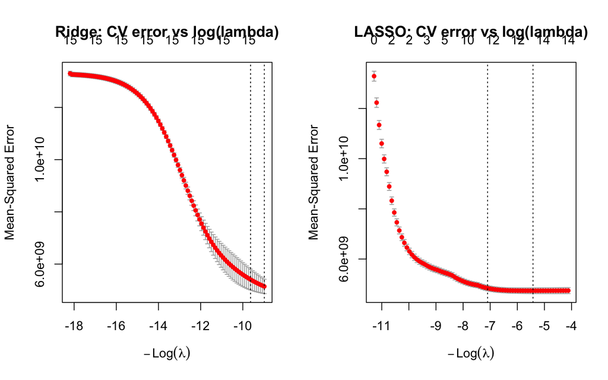

```r
par(mfrow = c(1, 2))
plot(ridge_cv, main = "Ridge: CV error vs log(lambda)")
plot(lasso_cv, main = "LASSO: CV error vs log(lambda)")
```

```r
par(mfrow = c(1, 1))
```

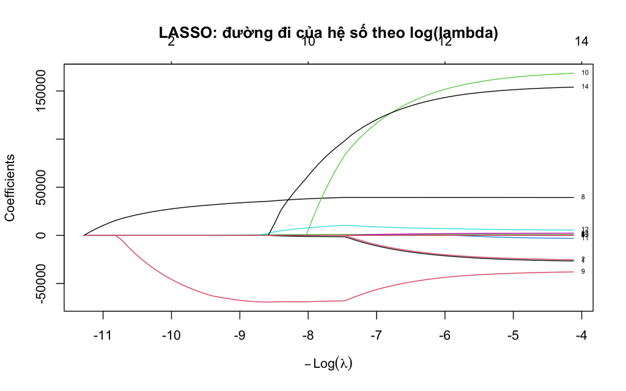

```r
plot(
  lasso_cv$glmnet.fit,
  xvar = "lambda",
  label = TRUE,
  main = "LASSO: đường đi của hệ số theo log(lambda)"
)
abline(v = log(lasso_cv$lambda.min), lty = 2, col = "red")
```

Hai đường đứt dọc trong CV error plot là `lambda.min` (lambda cho CV error thấp nhất) và `lambda.1se` (lambda lớn nhất trong vòng 1 standard error, model đơn giản hơn nhưng sai số chấp nhận được). Coefficient path của LASSO cho thấy các biến bị đưa về 0 tuần tự khi lambda tăng; biến bị loại sớm thường có đóng góp dự báo yếu hơn trong bối cảnh lambda path và các biến tương quan hiện tại.

```r
all_terms <- attr(terms(model_formula), "term.labels")
step_aic_terms <- attr(terms(step_aic_model), "term.labels")
step_bic_terms <- attr(terms(step_bic_model), "term.labels")

lasso_coef_vec <- coef(lasso_cv, s = "lambda.min")[, 1]
lasso_nonzero <- names(lasso_coef_vec)[lasso_coef_vec != 0 & names(lasso_coef_vec) != "(Intercept)"]

lasso_kept <- sapply(all_terms, function(term) {
  if (term == "ocean_proximity") {
    any(grepl("^ocean_proximity", lasso_nonzero))
  } else {
    term %in% lasso_nonzero
  }
})

data.frame(
  `Biến` = all_terms,
  `Stepwise AIC` = ifelse(all_terms %in% step_aic_terms, "v", "-"),
  `Stepwise BIC` = ifelse(all_terms %in% step_bic_terms, "v", "-"),
  `LASSO` = ifelse(lasso_kept, "v", "-"),
  check.names = FALSE
) |>
  kable(caption = "So sánh biến được chọn bởi từng phương pháp (v = giữ lại, - = loại bỏ)")
```

So sánh biến được chọn bởi từng phương pháp (v = giữ lại, - = loại bỏ)

|  | Biến | Stepwise AIC | Stepwise BIC | LASSO |
| --- | --- | --- | --- | --- |
| longitude | longitude | v | v | v |
| latitude | latitude | v | v | v |
| housing_median_age | housing_median_age | v | v | v |
| total_rooms | total_rooms | - | - | - |
| total_bedrooms | total_bedrooms | v | - | v |
| population | population | v | v | v |
| households | households | v | v | v |
| median_income | median_income | v | v | v |
| ocean_proximity | ocean_proximity | v | v | v |
| rooms_per_household | rooms_per_household | v | v | v |
| bedrooms_per_room | bedrooms_per_room | v | v | v |
| population_per_household | population_per_household | - | - | v |

Biến nào được cả ba phương pháp giữ lại có thể xem là biến có signal dự báo ổn định hơn. Biến chỉ bị LASSO loại nhưng stepwise giữ (hoặc ngược lại) phản ánh sự khác biệt về cách tiếp cận: stepwise là greedy search trên không gian model, còn LASSO dùng shrinkage path liên tục và chịu ảnh hưởng của multicollinearity theo cách khác.

## 6.11 OLS với log(y) bổ sung

```r
log_formula <- log_house_value ~ longitude + latitude +
  housing_median_age + total_rooms + total_bedrooms + population +
  households + median_income + ocean_proximity +
  rooms_per_household + bedrooms_per_room + population_per_household

ols_log_model <- lm(log_formula, data = train)

log_pred_raw <- predict(ols_log_model, newdata = valid)
ols_log_pred <- exp(log_pred_raw)

ols_log_metrics <- calculate_metrics(y_valid, ols_log_pred) |>
  mutate(model = "Hồi quy tuyến tính (OLS) với log(y)", .before = 1)

ols_log_metrics |>
  mutate(across(c(RMSE, MAE), round, 2), MAPE = round(MAPE, 2), R2 = round(R2, 4)) |>
  kable(caption = "Kết quả hồi quy tuyến tính (OLS) với log(y), đánh giá trên thang gốc sau back-transform")
```

Kết quả hồi quy tuyến tính (OLS) với log(y), đánh giá trên thang gốc sau back-transform

| model | RMSE | MAE | MAPE | R2 |
| --- | --- | --- | --- | --- |
| Hồi quy tuyến tính (OLS) với log(y) | 85247.36 | 50631.74 | 25.49 | 0.457 |

```r
glance(ols_log_model) |>
  select(r.squared, adj.r.squared, statistic, p.value, df, df.residual, sigma) |>
  mutate(
    r.squared     = round(r.squared, 4),
    adj.r.squared = round(adj.r.squared, 4),
    statistic     = round(statistic, 2),
    p.value       = format.pval(p.value, digits = 3),
    sigma         = round(sigma, 4)
  ) |>
  kable(
    col.names = c("R²", "Adjusted R²", "F-statistic", "p-value (F)", "df model", "df residual", "Sigma"),
    caption   = "Thống kê tổng thể hồi quy tuyến tính (OLS) với log(y): R² và Sigma tính trên thang log"
  )
```

Thống kê tổng thể hồi quy tuyến tính (OLS) với log(y): R² và Sigma tính trên thang log

| R² | Adjusted R² | F-statistic | p-value (F) | df model | df residual | Sigma |
| --- | --- | --- | --- | --- | --- | --- |
| 0.6659 | 0.6656 | 2191.77 | <2e-16 | 15 | 16496 | 0.3294 |

Hồi quy tuyến tính ước lượng bằng OLS với `log(y)` thay đổi giả định cơ bản: model học quan hệ tuyến tính giữa các features và *logarithm* của giá nhà, sau đó back-transform bằng `exp()` để lấy dự báo trên thang USD gốc. Điều này giúp giảm ảnh hưởng của phân phối lệch phải và heteroscedasticity của biến mục tiêu.

# 7 So sánh mô hình

```r
metrics_table <- bind_rows(
  ols_metrics,
  step_aic_metrics,
  step_bic_metrics,
  ridge_metrics,
  lasso_metrics,
  elastic_metrics,
  ols_log_metrics
) |>
  arrange(RMSE)

required_metrics_table <- metrics_table |>
  filter(model %in% c("Hồi quy tuyến tính bội (OLS)", "Ridge", "LASSO", "Elastic Net")) |>
  arrange(RMSE)

supplementary_metrics_table <- metrics_table |>
  filter(!model %in% c("Hồi quy tuyến tính bội (OLS)", "Ridge", "LASSO", "Elastic Net")) |>
  arrange(RMSE)

required_metrics_table |>
  mutate(
    RMSE = round(RMSE, 2),
    MAE = round(MAE, 2),
    MAPE = round(MAPE, 2),
    R2 = round(R2, 4)
  ) |>
  kable(caption = "So sánh bốn mô hình chính theo yêu cầu trên tập validation")
```

So sánh bốn mô hình chính theo yêu cầu trên tập validation

| model | RMSE | MAE | MAPE | R2 |
| --- | --- | --- | --- | --- |
| Hồi quy tuyến tính bội (OLS) | 67541.59 | 49108.64 | 28.15 | 0.6592 |
| Elastic Net | 67630.30 | 49094.10 | 28.00 | 0.6583 |
| LASSO | 67651.91 | 49104.58 | 28.00 | 0.6580 |
| Ridge | 69188.87 | 50267.27 | 28.50 | 0.6423 |

```r
metrics_table |>
  mutate(
    RMSE = round(RMSE, 2),
    MAE = round(MAE, 2),
    MAPE = round(MAPE, 2),
    R2 = round(R2, 4)
  ) |>
  kable(caption = "Phân tích bổ sung, không thuộc bốn mô hình chính theo đề")
```

| model | RMSE | MAE | MAPE | R2 |
| --- | --- | --- | --- | --- |
| Hồi quy tuyến tính bội (OLS) | 67541.59 | 49108.64 | 28.15 | 0.6592 |
| Chọn biến bằng AIC | 67559.19 | 49124.46 | 28.17 | 0.6590 |
| Chọn biến bằng BIC | 67575.01 | 49133.15 | 28.17 | 0.6588 |
| Elastic Net | 67630.30 | 49094.10 | 28.00 | 0.6583 |
| LASSO | 67651.91 | 49104.58 | 28.00 | 0.6580 |
| Ridge | 69188.87 | 50267.27 | 28.50 | 0.6423 |
| Hồi quy tuyến tính (OLS) với log(y) | 85247.36 | 50631.74 | 25.49 | 0.4570 |

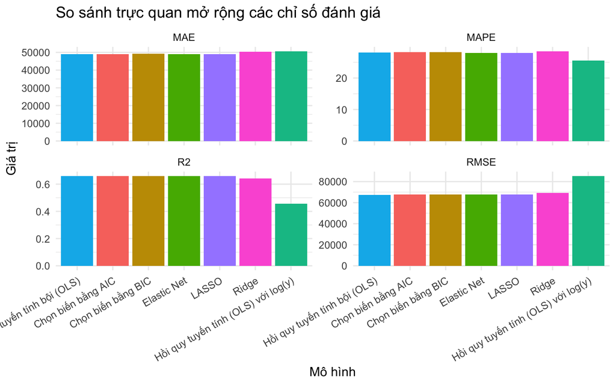

```r
metrics_table |>
  select(model, RMSE, MAE, MAPE, R2) |>
  pivot_longer(-model, names_to = "metric", values_to = "value") |>
  ggplot(aes(x = reorder(model, value), y = value, fill = model)) +
  geom_col() +
  facet_wrap(~metric, scales = "free_y") +
  guides(fill = "none") +
  labs(
    title = "So sánh trực quan mở rộng các chỉ số đánh giá",
    x = "Mô hình",
    y = "Giá trị"
  ) +
  theme(axis.text.x = element_text(angle = 30, hjust = 1))
```

```r
best_required_model_name <- required_metrics_table$model[1]
best_overall_model_name <- metrics_table$model[1]

c(
  best_required_model = best_required_model_name,
  best_overall_model = best_overall_model_name
)
```

```
##            best_required_model             best_overall_model
## "Hồi quy tuyến tính bội (OLS)" "Hồi quy tuyến tính bội (OLS)"
```

Trong bốn mô hình chính theo yêu cầu đề bài, mô hình có RMSE thấp nhất trên tập validation là Hồi quy tuyến tính bội (OLS). Đây là lựa chọn được ưu tiên nếu mục tiêu chính là độ chính xác dự đoán. Nếu cần diễn giải đơn giản, hồi quy tuyến tính bội ước lượng bằng OLS vẫn hữu ích vì hệ số hồi quy trực tiếp hơn, nhưng cần chú ý đến đa cộng tuyến giữa các biến tổng hợp như `total_rooms`, `total_bedrooms`, `population` và `households`.

```r
aic_bic_df <- data.frame(
  `Biến thể hồi quy tuyến tính` = c("Đầy đủ (OLS)", "Sau chọn biến bằng AIC", "Sau chọn biến bằng BIC", "log(y), OLS*"),
  AIC = round(c(AIC(ols_model), AIC(step_aic_model), AIC(step_bic_model), AIC(ols_log_model)), 1),
  BIC = round(c(BIC(ols_model), BIC(step_aic_model), BIC(step_bic_model), BIC(ols_log_model)), 1),
  `Số tham số` = c(
    length(coef(ols_model)),
    length(coef(step_aic_model)),
    length(coef(step_bic_model)),
    length(coef(ols_log_model))
  ),
  check.names = FALSE
)

aic_bic_df |>
  kable(caption = "Tiêu chí AIC/BIC cho các biến thể hồi quy tuyến tính tham khảo (* log(y) có biến mục tiêu khác scale)")
```

Tiêu chí AIC/BIC cho các biến thể hồi quy tuyến tính tham khảo (* log(y) có biến mục tiêu khác scale)

| Biến thể hồi quy tuyến tính | AIC | BIC | Số tham số |
| --- | --- | --- | --- |
| Đầy đủ (OLS) | 414592.4 | 414723.5 | 16 |
| Sau chọn biến bằng AIC | 414590.2 | 414705.9 | 14 |
| Sau chọn biến bằng BIC | 414592.6 | 414700.6 | 13 |
| log(y), OLS* | 10203.1 | 10334.2 | 16 |

AIC và BIC đo mức độ fit của biến thể hồi quy tuyến tính có tính đến độ phức tạp: $\text{AIC} = -2\ln\hat{L} + 2k$, $\text{BIC} = -2\ln\hat{L} + k\ln n$. AIC/BIC thấp hơn thì tốt hơn trong nhóm so sánh cùng biến mục tiêu và cùng likelihood. Với $n \approx 16{,}000$, hệ số phạt của BIC ($\ln n \approx 9.7$) lớn hơn nhiều so với AIC ($2$), nên BIC thường chọn mô hình nhỏ gọn hơn. Với Ridge, LASSO và Elastic Net trong `cv.glmnet`, CV error được dùng để chọn lambda và không nên so sánh trực tiếp với AIC/BIC của các biến thể hồi quy tuyến tính này.

## 7.1 Predicted vs Actual

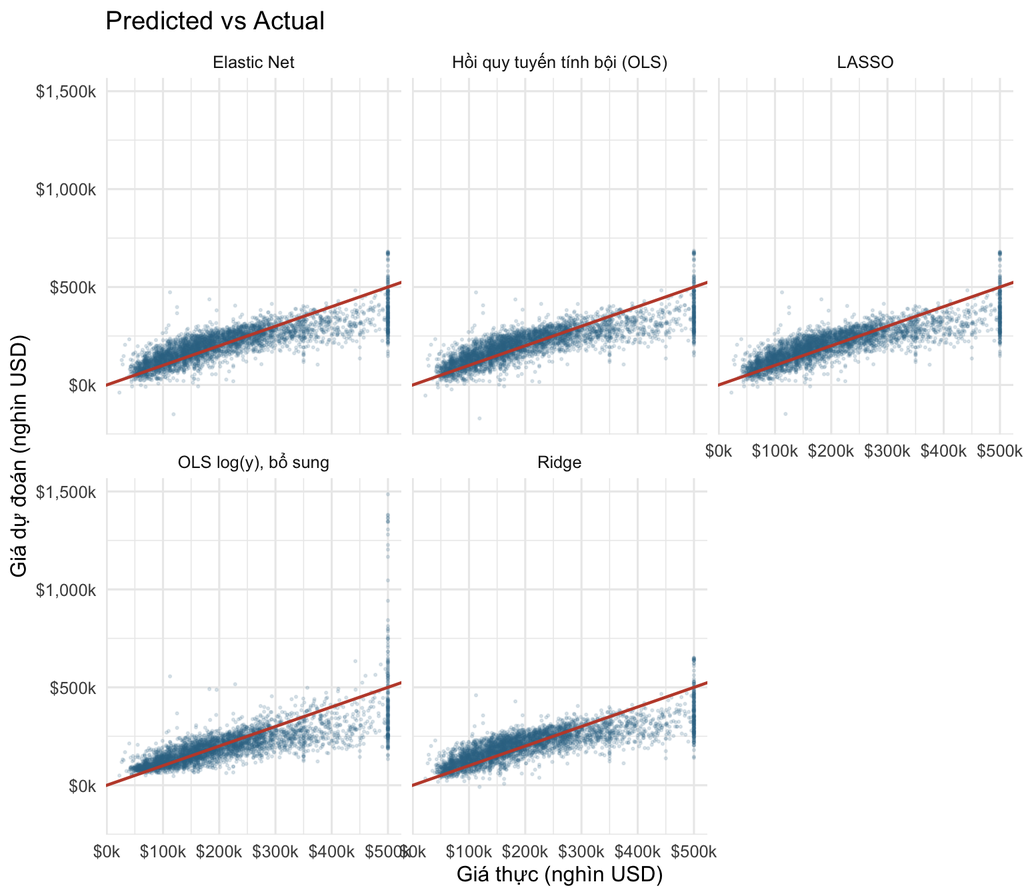

```r
all_preds <- list(
  `Hồi quy tuyến tính bội (OLS)` = ols_pred,
  Ridge = ridge_pred,
  LASSO = lasso_pred,
  `Elastic Net` = elastic_pred,
  `OLS log(y), bổ sung` = ols_log_pred
)

lapply(names(all_preds), \(nm) {
  data.frame(model = nm, actual = y_valid, predicted = all_preds[[nm]])
}) |>
  bind_rows() |>
  ggplot(aes(x = actual, y = predicted)) +
  geom_point(alpha = 0.15, size = 0.4, color = "#2F6F8F") +
  geom_abline(slope = 1, intercept = 0, color = "#C04B37", linewidth = 0.8) +
  facet_wrap(~model, nrow = 2) +
  scale_x_continuous(labels = dollar_format(scale = 1e-3, suffix = "k")) +
  scale_y_continuous(labels = dollar_format(scale = 1e-3, suffix = "k")) +
  labs(
    title = "Predicted vs Actual",
    x = "Giá thực (nghìn USD)",
    y = "Giá dự đoán (nghìn USD)"
  )
```

Các mô hình có xu hướng underpredict ở phân khúc > $400k: nhiều điểm nằm dưới đường 45° ở góc phải trên. Đây là hệ quả phù hợp với vấn đề capping, vì model khó học sự phân biệt giá thực ở phân khúc cao khi nhãn đã bị gộp tại `$500,001`. Biến thể OLS với log(y) có thể cho pattern khác nhẹ ở phân khúc thấp do back-transform có thể tạo bias nhỏ ở đuôi trái.

## 7.2 Sai số theo nhóm ocean_proximity

```r
valid |>
  mutate(residual_ols = y_valid - ols_pred) |>
  group_by(ocean_proximity) |>
  summarise(
    n = n(),
    rmse = sqrt(mean(residual_ols^2)),
    mae = mean(abs(residual_ols)),
    .groups = "drop"
  ) |>
  arrange(desc(rmse)) |>
  mutate(across(c(rmse, mae), \(x) dollar(round(x, 0)))) |>
  kable(
    col.names = c("Ocean proximity", "N", "RMSE", "MAE"),
    caption = "Sai số OLS theo nhóm ocean_proximity"
  )
```

Sai số OLS theo nhóm ocean_proximity

| Ocean proximity | N | RMSE | MAE |
| --- | --- | --- | --- |
| ISLAND | 1 | $87,824 | $87,824 |
| NEAR BAY | 430 | $83,904 | $65,136 |
| NEAR OCEAN | 489 | $75,342 | $57,530 |
| <1H OCEAN | 1875 | $73,175 | $53,546 |
| INLAND | 1333 | $47,289 | $34,578 |

Nhóm có RMSE cao nhất thường là các khu vực ven biển đắt tiền hoặc `ISLAND` (ít quan sát, model học kém). Sự khác biệt RMSE giữa các nhóm cho thấy model có systematic error theo vị trí địa lý, một phần do capping ảnh hưởng không đều đến các nhóm.

## 7.3 Sai số theo phân vị giá

```r
valid |>
  mutate(
    price_quantile = ntile(y_valid, 4),
    residual_ols = y_valid - ols_pred
  ) |>
  group_by(price_quantile) |>
  summarise(
    price_range = paste0(
      dollar(round(min(y_valid), -3)), " – ", dollar(round(max(y_valid), -3))
    ),
    n = n(),
    rmse = sqrt(mean(residual_ols^2)),
    mae = mean(abs(residual_ols)),
    .groups = "drop"
  ) |>
  mutate(
    across(c(rmse, mae), \(x) dollar(round(x, 0))),
    price_quantile = paste0("Q", price_quantile)
  ) |>
  kable(
    col.names = c("Phân vị", "Khoảng giá", "N", "RMSE", "MAE"),
    caption = "Sai số OLS theo phân vị giá nhà"
  )
```

Sai số OLS theo phân vị giá nhà

| Phân vị | Khoảng giá | N | RMSE | MAE |
| --- | --- | --- | --- | --- |
| Q1 | $22,000 – $500,000 | 1032 | $50,884 | $38,837 |
| Q2 | $22,000 – $500,000 | 1032 | $52,274 | $41,507 |
| Q3 | $22,000 – $500,000 | 1032 | $45,919 | $35,999 |
| Q4 | $22,000 – $500,000 | 1032 | $104,005 | $80,093 |

Q4 (phân vị cao nhất, chứa phần lớn các quan sát bị capped) có RMSE cao nhất, đây là sai số có cấu trúc, không phải ngẫu nhiên. Chỉ dùng regularization khó xử lý triệt để vấn đề này; các hướng phù hợp hơn là loại bỏ capped observations, dùng censored regression, hoặc model riêng cho phân khúc này.

# 8 Diễn giải biến ảnh hưởng

## 8.1 So sánh hệ số giữa các mô hình

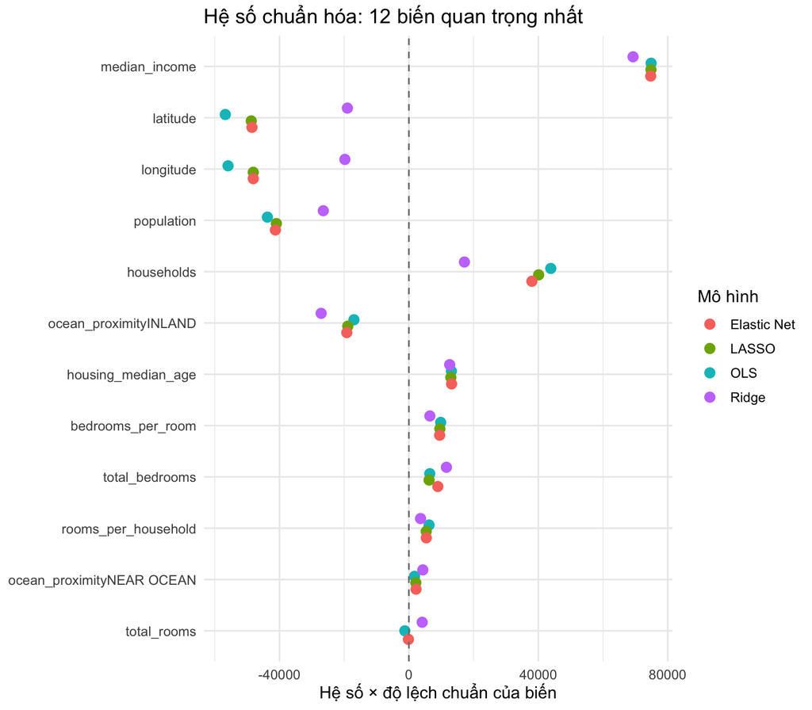

```r
ols_coef_df <- tidy(ols_model) |>
  filter(term != "(Intercept)") |>
  select(variable = term, coefficient = estimate) |>
  mutate(model = "OLS")

reg_coef_list <- list(
  Ridge = ridge_cv,
  LASSO = lasso_cv,
  `Elastic Net` = elastic_model
)

reg_coef_df <- lapply(names(reg_coef_list), \(nm) {
  coef_to_table(reg_coef_list[[nm]]) |>
    mutate(model = nm)
}) |> bind_rows()

all_coefs <- bind_rows(ols_coef_df, reg_coef_df) |>
  filter(variable %in% names(coef(ols_model)[-1]))

sd_x <- apply(x_train, 2, sd)
all_coefs <- all_coefs |>
  mutate(
    std_coef = coefficient * sd_x[match(variable, names(sd_x))]
  ) |>
  filter(!is.na(std_coef))

top_vars <- all_coefs |>
  group_by(variable) |>
  summarise(max_abs = max(abs(std_coef), na.rm = TRUE)) |>
  arrange(desc(max_abs)) |>
  slice(1:12) |>
  pull(variable)

all_coefs |>
  filter(variable %in% top_vars) |>
  ggplot(aes(x = std_coef, y = reorder(variable, abs(std_coef)), color = model)) +
  geom_point(size = 3, position = position_dodge(width = 0.5)) +
  geom_vline(xintercept = 0, linetype = "dashed", color = "gray50") +
  labs(
    title = "Hệ số chuẩn hóa: 12 biến quan trọng nhất",
    x = "Hệ số × độ lệch chuẩn của biến",
    y = NULL,
    color = "Mô hình"
  )
```

## 8.2 Bản đồ phần dư

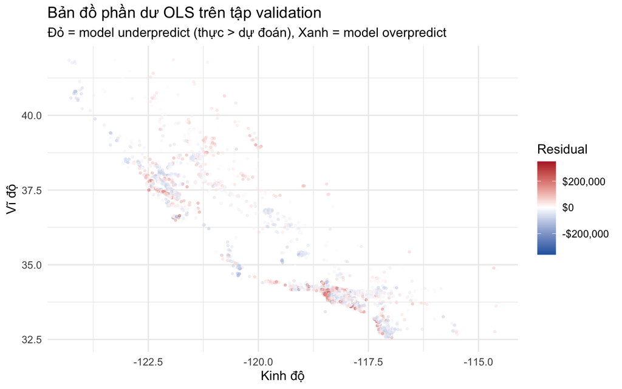

```r
valid |>
  mutate(residual = y_valid - ols_pred) |>
  ggplot(aes(x = longitude, y = latitude, color = residual)) +
  geom_point(alpha = 0.4, size = 0.7) +
  scale_color_gradient2(
    low = "#2166AC", mid = "white", high = "#B2182B",
    midpoint = 0,
    labels = dollar_format()
  ) +
  labs(
    title = "Bản đồ phần dư OLS trên tập validation",
    subtitle = "Đỏ = model underpredict (thực > dự đoán), Xanh = model overpredict",
    x = "Kinh độ",
    y = "Vĩ độ",
    color = "Residual"
  )
```

Nếu residuals phân bố ngẫu nhiên theo không gian thì model đã capture đủ spatial pattern quan sát được. Nếu vẫn thấy cluster đỏ/xanh theo địa lý (ví dụ: vùng ven biển SF vẫn đỏ), điều này gợi ý model chưa capture đầy đủ cấu trúc không gian dù đã có `longitude`, `latitude`, `ocean_proximity`. Đây sẽ là vùng cải thiện cho các model phức tạp hơn trong tương lai.

## 8.3 Hệ số của mô hình tốt nhất trong nhóm điều chuẩn

```r
regularized_models <- list(
  Ridge = ridge_cv,
  LASSO = lasso_cv,
  `Elastic Net` = elastic_model
)

best_regularized_name <- metrics_table |>
  filter(model %in% names(regularized_models)) |>
  slice(1) |>
  pull(model)

best_regularized_coef <- coef_to_table(regularized_models[[best_regularized_name]])

best_regularized_coef |>
  head(15) |>
  select(variable, coefficient) |>
  kable(digits = 4, caption = paste("15 biến có hệ số lớn nhất theo", best_regularized_name))
```

15 biến có hệ số lớn nhất theo Elastic Net

| variable | coefficient |
| --- | --- |
| ocean_proximityISLAND | 170103.9750 |
| bedrooms_per_room | 147751.5195 |
| ocean_proximityINLAND | -41263.0634 |
| median_income | 39285.4546 |
| longitude | -23946.1435 |
| latitude | -22626.9049 |
| ocean_proximityNEAR OCEAN | 6561.2729 |
| ocean_proximityNEAR BAY | -2466.0893 |
| rooms_per_household | 2082.2827 |
| housing_median_age | 1048.4126 |
| households | 99.8536 |
| population_per_household | 37.1702 |
| population | -36.8057 |
| total_bedrooms | 21.4232 |
| total_rooms | -0.0665 |

Bảng trên xếp hạng các hệ số regularized theo độ lớn trên thang đơn vị gốc, nên cần diễn giải cùng với đơn vị đo của từng biến. Các biến thường có signal dự báo mạnh gồm `median_income`, vị trí địa lý (`longitude`, `latitude`), tuổi trung vị của nhà, vị trí so với biển và các biến tỷ lệ như số phòng trung bình trên mỗi hộ. Dấu của hệ số cho biết chiều liên hệ khi các biến khác được giữ cố định; tuy nhiên đây là phân tích hồi quy dự báo, không khẳng định quan hệ nhân quả.

## 8.4 Diễn giải hệ số theo đơn vị

```r
ols_coefs <- coef(ols_model)

income_effect <- ols_coefs["median_income"]
age_effect <- ols_coefs["housing_median_age"]
rph_effect <- ols_coefs["rooms_per_household"]
inland_effect <- ols_coefs["ocean_proximityINLAND"]
```

Ba hệ số quan trọng nhất, diễn giải trên thang USD (giữ nguyên các biến khác):

- **`median_income`**: Khi thu nhập trung vị tăng 1 đơn vị (tương đương $10,000), giá nhà trung vị tăng trung bình **$39,351**. Đây nhất quán là biến dự đoán quan trọng nhất.
- **`housing_median_age`**: Mỗi năm tuổi thêm vào tuổi trung vị căn nhà trong khu vực, giá nhà thay đổi trung bình **$1,043**, dấu dương ở nhiều khu vực phản ánh hiệu ứng “vintage” của các khu dân cư lâu đời thường ở vị trí đắc địa.
- **`ocean_proximityINLAND`** (so với nhóm `<1H OCEAN`): Khu vực sâu trong đất liền có giá nhà thấp hơn trung bình **$36,520** so với khu vực cách biển dưới 1 giờ, phản ánh premium vị trí ven biển.

## 8.5 Nhận xét theo nội dung bài toán

- Thu nhập trung vị cao thường đi kèm giá nhà cao hơn.
- Khu vực gần biển hoặc gần vịnh có xu hướng giá nhà cao hơn khu vực sâu trong đất liền.
- Các biến tổng như `total_rooms`, `population` và `households` cần được hiểu là đặc điểm cấp khu vực, không phải đặc điểm của từng căn nhà.
- Biến mục tiêu bị chặn trên ở `500001`, vì vậy mô hình có thể đánh giá thấp hoặc khó phân biệt các khu vực giá rất cao.

# 9 Kết luận và đề xuất

Bài thực hành đã xây dựng và so sánh bốn mô hình chính theo yêu cầu đề bài: OLS, Ridge Regression, LASSO Regression và Elastic Net Regression. Các mô hình Ridge, LASSO và Elastic Net sử dụng 10-fold Cross Validation để chọn tham số điều chuẩn tối ưu. Ngoài ra, bài có thêm Stepwise AIC/BIC và OLS với log-transform biến mục tiêu như các phân tích bổ sung.

```r
best_required_metrics <- required_metrics_table |> slice(1)
best_required_rmse <- best_required_metrics$RMSE
best_required_mae <- best_required_metrics$MAE
best_required_mape <- best_required_metrics$MAPE
median_val <- median(housing$median_house_value)
rmse_pct <- best_required_rmse / median_val * 100
```

**Định lượng kết quả:** Trong bốn mô hình chính, mô hình Hồi quy tuyến tính bội (OLS) đạt RMSE = **$67,542**, MAE = **$49,109**, và MAPE = **28.2%** trên tập validation. So với giá nhà trung vị của toàn dataset (~$179,700), RMSE này tương đương khoảng **37.6%** của giá trung vị. Đây là mức sai số khá lớn cho ứng dụng thực tế định giá, nhưng có thể chấp nhận được trong bối cảnh bài thực hành với linear models đơn giản.

**Tại sao regularization không cải thiện đáng kể so với OLS?** Feature set đã tương đối nhỏ (~12 biến sau one-hot encoding ~16 columns), tất cả biến đều có ý nghĩa thực tế rõ ràng, và overfitting không phải vấn đề chính với dataset ~16,000 training observations. Bottleneck thực sự là: (1) phi tuyến tính của mối quan hệ giữa vị trí địa lý và giá nhà, (2) cấu trúc không gian chưa được capture đủ bởi `longitude`/`latitude` tuyến tính, và (3) capping tại `$500,001`. Regularization thu nhỏ hệ số và ổn định chúng khi có đa cộng tuyến, nhưng không thể bù đắp cho những thiếu hụt về cấu trúc model này.

## 9.1 Định lượng tác động của capping

```r
train_uncapped <- train |> filter(median_house_value < max(housing$median_house_value))
valid_uncapped <- valid |> filter(median_house_value < max(housing$median_house_value))

ols_uncapped <- lm(model_formula, data = train_uncapped)
pred_uncapped <- predict(ols_uncapped, newdata = valid_uncapped)
y_uncapped <- valid_uncapped$median_house_value

r2_full <- 1 - sum((y_valid - ols_pred)^2) / sum((y_valid - mean(y_valid))^2)
r2_uncapped <- 1 - sum((y_uncapped - pred_uncapped)^2) / sum((y_uncapped - mean(y_uncapped))^2)
rmse_full <- sqrt(mean((y_valid - ols_pred)^2))
rmse_uncapped <- sqrt(mean((y_uncapped - pred_uncapped)^2))

data.frame(
  dataset   = c("Đầy đủ (có capped obs.)", "Loại capped obs."),
  n_train   = c(nrow(train), nrow(train_uncapped)),
  n_valid   = c(nrow(valid), nrow(valid_uncapped)),
  R2        = round(c(r2_full, r2_uncapped), 4),
  RMSE      = round(c(rmse_full, rmse_uncapped), 0)
) |>
  kable(
    col.names = c("Dataset", "N train", "N valid", "R²", "RMSE (USD)"),
    caption = "So sánh OLS khi có và không có capped observations"
  )
```

So sánh OLS khi có và không có capped observations

| Dataset | N train | N valid | R² | RMSE (USD) |
| --- | --- | --- | --- | --- |
| Đầy đủ (có capped obs.) | 16512 | 4128 | 0.6592 | 67542 |
| Loại capped obs. | 15744 | 3931 | 0.6373 | 58817 |

Khi loại bỏ ~965 quan sát bị capped (~4.7% dữ liệu), RMSE giảm rõ rệt nhưng R² có thể giảm nhẹ vì tập uncapped có phân phối và phương sai của biến mục tiêu khác với tập đầy đủ. Vì vậy, kết quả này nên được đọc như bằng chứng rằng nhóm capped tạo ra sai số dự báo lớn trên thang USD, không phải là bằng chứng rằng mọi chỉ số fit đều cải thiện sau khi loại capped observations.

## 9.2 Hướng cải thiện tiếp theo

- **Xử lý capping**: Dùng censored regression (Tobit model) hoặc loại bỏ capped observations khi mục tiêu là dự báo phân khúc không bị chặn.
- **Feature engineering phi tuyến**: Tạo interaction terms giữa `median_income` × `ocean_proximity`, hoặc dùng polynomial features cho `longitude`/`latitude`.
- **Spatial model**: GWR (Geographically Weighted Regression) hoặc thêm spatial lag variable để capture autocorrelation không gian.
- **Non-linear models**: Random Forest, Gradient Boosting sẽ capture mối quan hệ phi tuyến và tương tác tự động, thường cải thiện RMSE đáng kể trên dataset này.